# Análisis de la Depresión Estudiantil

Student Depression Dataset

Angelo Alejandro Ibañez Hernandez 20212020007 Alejandro Gomez Moyano 20222020073 Juan David Córdoba Aguirre 20211020097 Oscar Santiago Duran Benitez 20212020080

28/05/2026

# PARTE 1 - DATASET

## 1. Descripción del conjunto de datos

El dataset utilizado corresponde a un conjunto de datos sobre depresión en estudiantes, el cual contiene información relacionada con factores académicos, personales y de salud mental.

Este dataset cuenta con aproximadamente 27,901 registros y 18 variables, incluyendo tanto variables cualitativas como cuantitativas.

### Tipo de problema

El conjunto de datos es adecuado para un problema de clasificación, ya que contiene una variable objetivo denominada `Depression`, la cual indica si un estudiante presenta depresión (1) o no (0).

### Justificación del dataset

Este dataset es pertinente para un análisis estadístico multidimensional debido a que:

- Contiene múltiples variables que describen diferentes dimensiones del individuo (académica, personal, económica y psicológica).
- Permite analizar relaciones entre variables que potencialmente influyen en la depresión.
- Presenta una combinación de variables numéricas y categóricas, lo cual es ideal para análisis univariado, bivariado y multivariado.

### Carga del Dataset

```r
data <- read.csv("Student Depression Dataset.csv", stringsAsFactors = FALSE)
```

# PARTE 2 - ANÁLISIS UNIVARIADO

En esta sección se analizan todas las variables del dataset de manera individual. Se clasifican según su tipo y se justifica su relevancia dentro del análisis de depresión estudiantil.

## 🔹 Clasificación general de variables

### Variables cuantitativas

- Age
- Academic Pressure
- Work Pressure
- CGPA
- Study Satisfaction
- Job Satisfaction
- Work/Study Hours
- Financial Stress

### Variables cualitativas

- Gender
- City
- Profession
- Degree
- Sleep Duration
- Dietary Habits
- Suicidal Thoughts
- Family History of Mental Illness
- Depression

# 🔹 VARIABLES CUANTITATIVAS

## Edad (Age)

### Tipo de variable

Cuantitativa discreta

### Justificación

La edad es fundamental en estudios de salud mental, ya que diferentes etapas de la vida presentan distintos niveles de vulnerabilidad psicológica.

### Gráficos

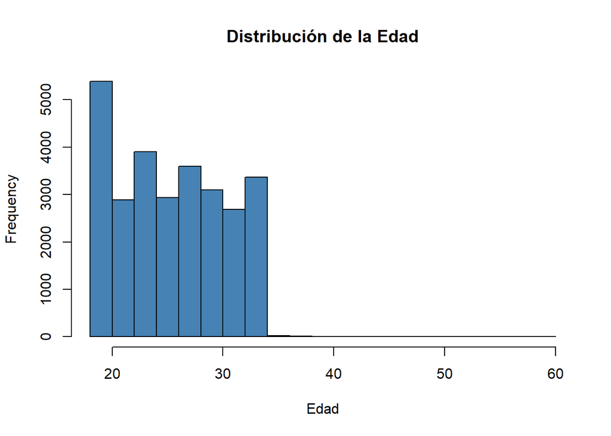

```r
hist(data$Age, col = "steelblue", xlab = "Edad" , main = "Distribución de la Edad")
```

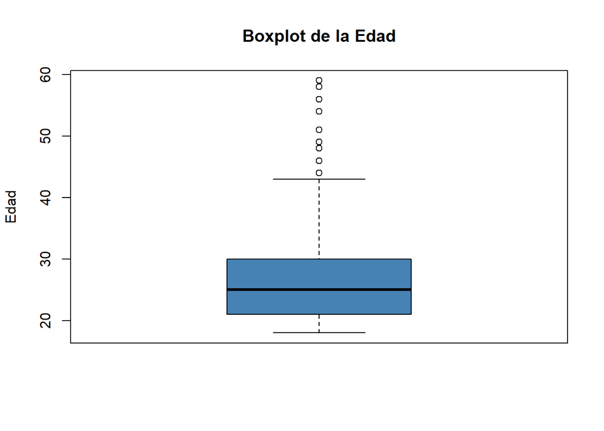

```r
boxplot(data$Age, col = "steelblue",ylab = "Edad" , main = "Boxplot de la Edad")
```

```r
mean(data$Age, na.rm = TRUE)
```

```
## [1] 25.8223
```

```r
median(data$Age, na.rm = TRUE)
```

```
## [1] 25
```

```r
sd(data$Age, na.rm = TRUE)
```

```
## [1] 4.905687
```

La distribución muestra una alta concentración entre los 18 y 27 años, lo cual confirma que la muestra representa principalmente estudiantes universitarios tradicionales. Sin embargo, la presencia de un segundo grupo entre los 28 y 35 años evidencia una población no homogénea, posiblemente compuesta por estudiantes de posgrado o educación continua.

El boxplot evidencia valores atípicos en edades superiores a 45 años, lo que sugiere casos aislados. Estos no deben eliminarse automáticamente, pero sí considerarse en análisis posteriores, ya que pueden introducir sesgos si no se controlan.

La edad no solo describe la población, sino que podria sugerir que la depresión deberia analizarse considerando diferencias generacionales, ya que las causas pueden variar entre estudiantes jóvenes y adultos.

## Presión Académica (Academic Pressure)

### Tipo de variable

Cuantitativa ordinal

### Justificación

Es una de las variables más relevantes, ya que la carga académica es un factor directamente asociado con el estrés y la depresión en estudiantes.

### Gráficos

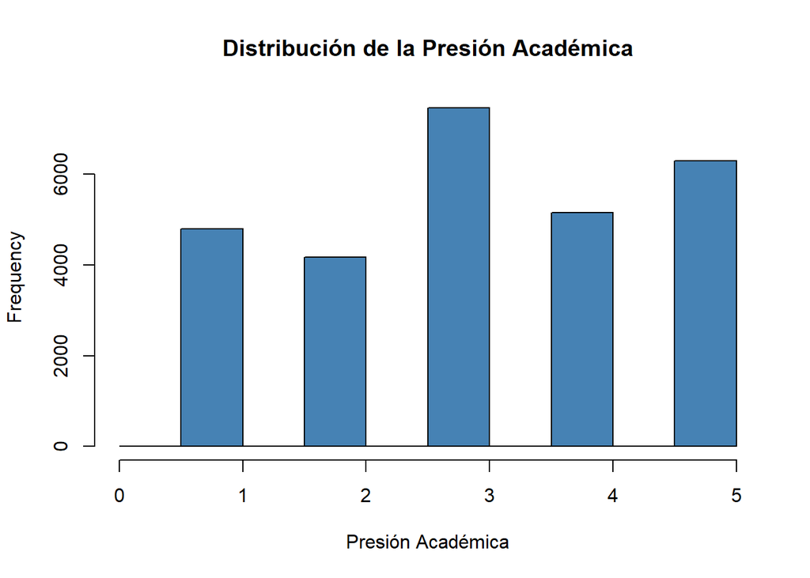

```r
hist(data$Academic.Pressure, col = "steelblue", xlab = "Presión Académica" , main = "Distribución de la Presión Académica")
```

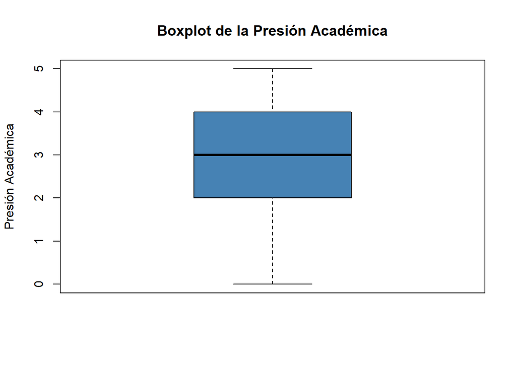

```r
boxplot(data$Academic.Pressure, col = "steelblue",ylab = "Presión Académica" , main = "Boxplot de la Presión Académica")
```

```r
mean(data$Academic.Pressure, na.rm = TRUE)
```

```
## [1] 3.141214
```

```r
median(data$Academic.Pressure, na.rm = TRUE)
```

```
## [1] 3
```

```r
sd(data$Academic.Pressure, na.rm = TRUE)
```

```
## [1] 1.381465
```

La distribución se concentra en valores medios-altos (3 a 5), lo que indica que la presión académica es una condición generalizada en la muestra.

La baja dispersión relativa sugiere que la presión no es un fenómeno aislado, sino estructural dentro del entorno estudiantil.

Más que un factor diferenciador, la presión académica parece ser una condición base del sistema educativo, por lo que su impacto en la depresión debe analizarse en combinación con otras variables (no de forma aislada).

## Presión Laboral (Work Pressure)

### Justificación

Permite analizar el impacto del trabajo en estudiantes que estudian y trabajan simultáneamente.

### Gráficos

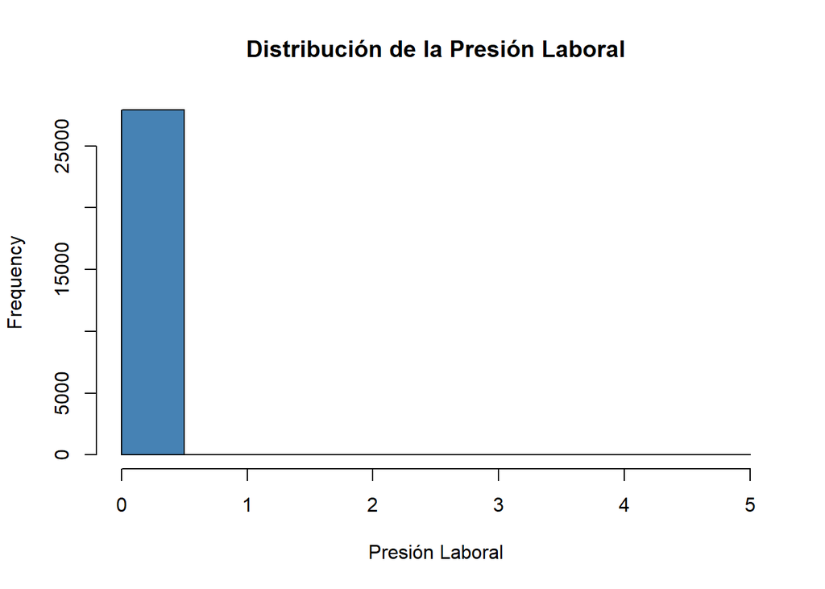

```r
hist(data$Work.Pressure, col = "steelblue", xlab = "Presión Laboral" , main = "Distribución de la Presión Laboral")
```

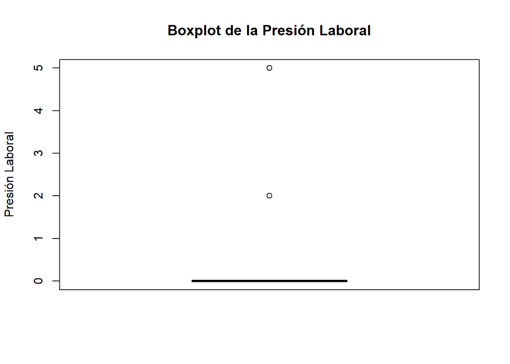

```r
boxplot(data$Work.Pressure, col = "steelblue",ylab = "Presión Laboral" , main = "Boxplot de la Presión Laboral")
```

```r
mean(data$Work.Pressure, na.rm = TRUE)
```

```
## [1] 0.0004300921
```

```r
median(data$Work.Pressure, na.rm = TRUE)
```

```
## [1] 0
```

```r
sd(data$Work.Pressure, na.rm = TRUE)
```

```
## [1] 0.04399203
```

La distribución está completamente sesgada hacia el valor 0, lo que indica ausencia casi total de presión laboral.

Esta variable no tiene capacidad explicativa en este dataset y debería:

- eliminarse del modelo, o
- utilizarse únicamente para confirmar que la población es mayoritariamente no trabajadora.

## CGPA (Rendimiento académico)

### Tipo de variable

Cuantitativa continua

### Justificación

El rendimiento académico puede influir directamente en el bienestar emocional.

### Gráficos

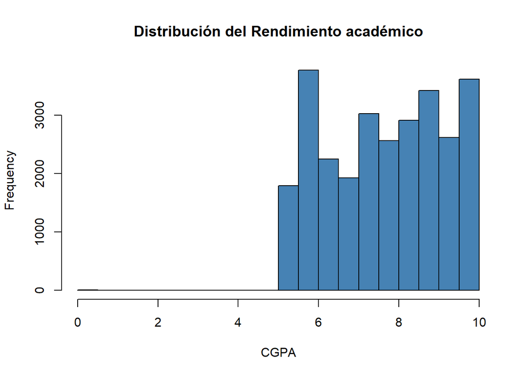

```r
hist(data$CGPA, col = "steelblue", xlab = "CGPA" , main = "Distribución del Rendimiento académico")
```

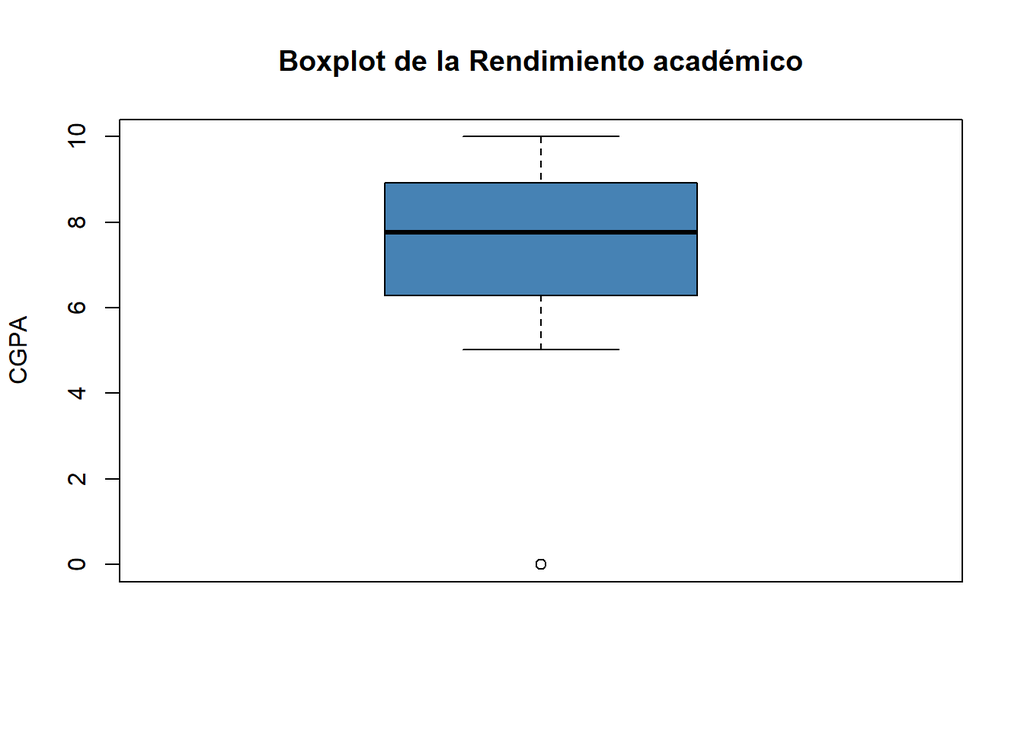

```r
boxplot(data$CGPA, col = "steelblue",ylab = "CGPA" , main = "Boxplot de la Rendimiento académico")
```

```r
mean(data$CGPA, na.rm = TRUE)
```

```
## [1] 7.656104
```

```r
median(data$CGPA, na.rm = TRUE)
```

```
## [1] 7.77
```

```r
sd(data$CGPA, na.rm = TRUE)
```

```
## [1] 1.470707
```

Esto indica que:

- la mayoría de estudiantes tiene buen rendimiento
- no hay una gran variabilidad académica

El alto rendimiento no actúa como factor protector contra la depresión, Por el contrario, puede estar asociado a:

- autoexigencia
- presión por mantener resultados

Esto sugerir una relación interesante: “alto rendimiento ≠ bienestar emocional”

## Estrés financiero

### Tipo de variable

Cuantitativa ordinal

### Justificación

El estrés económico es un factor clave en la salud mental.

### Gráficos

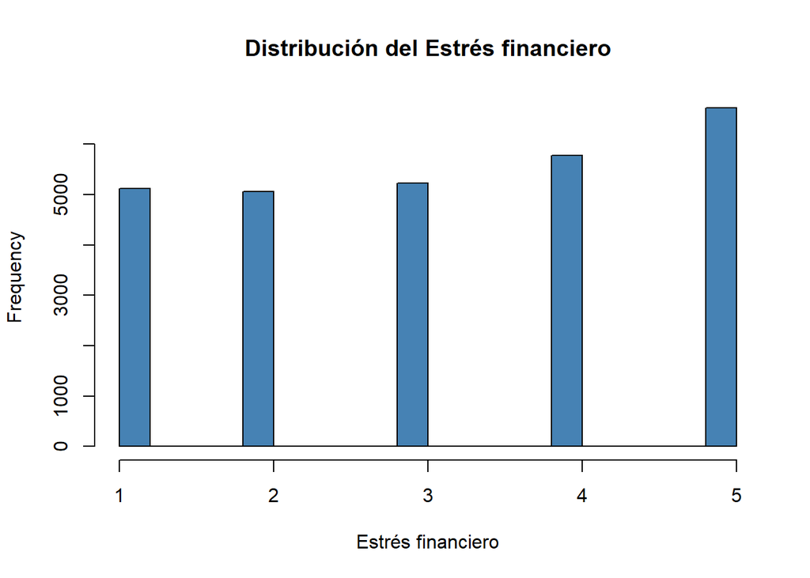

```r
hist(data$Financial.Stress, col = "steelblue", xlab = "Estrés financiero" , main = "Distribución del Estrés financiero")
```

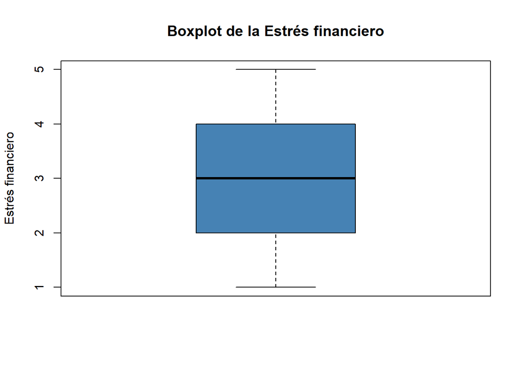

```r
boxplot(data$Financial.Stress, col = "steelblue",ylab = "Estrés financiero" , main = "Boxplot de la Estrés financiero")
```

```r
mean(data$Financial.Stress, na.rm = TRUE)
```

```
## [1] 3.139867
```

```r
median(data$Financial.Stress, na.rm = TRUE)
```

```
## [1] 3
```

```r
sd(data$Financial.Stress, na.rm = TRUE)
```

```
## [1] 1.437347
```

No es correcto decir que es homogéneo; porque hay suficiente variabilidad.

El estrés financiero sí puede ser un factor discriminante importante, especialmente porque:

- no todos los estudiantes lo experimentan igual
- puede interactuar con otras variables (horas de trabajo, sueño, etc.)

## Horas de estudio/trabajo (Work/Study Hours)

### Justificación

Relaciona carga diaria con fatiga.

### Gráficos

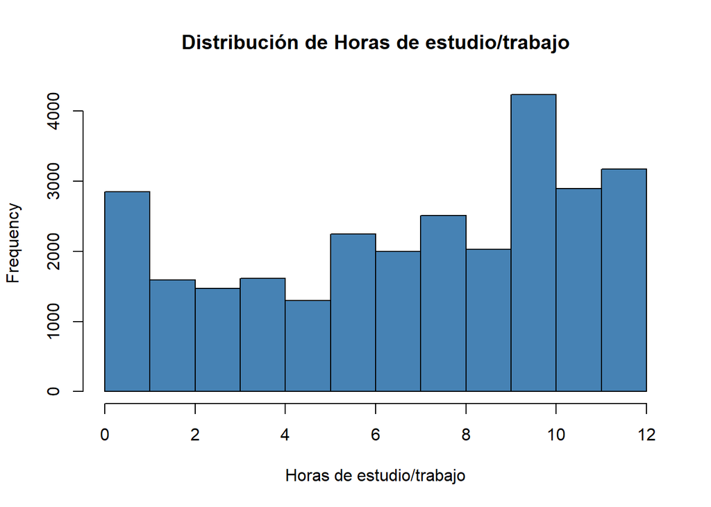

```r
hist(data$Work.Study.Hours, col = "steelblue", xlab = "Horas de estudio/trabajo" , main = "Distribución de Horas de estudio/trabajo")
```

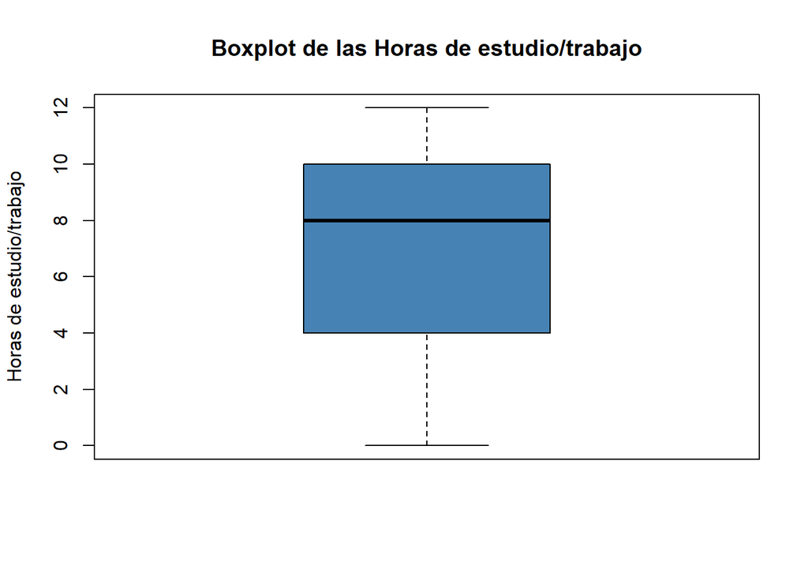

```r
boxplot(data$Work.Study.Hours, col = "steelblue",ylab = "Horas de estudio/trabajo" , main = "Boxplot de las Horas de estudio/trabajo")
```

```r
mean(data$Work.Study.Hours, na.rm = TRUE)
```

```
## [1] 7.156984
```

```r
median(data$Work.Study.Hours, na.rm = TRUE)
```

```
## [1] 8
```

```r
sd(data$Work.Study.Hours, na.rm = TRUE)
```

```
## [1] 3.707642
```

Existe un grupo importante en riesgo de sobrecarga académica, lo que puede derivar en:

- fatiga
- burnout
- alteraciones del sueño

## Género (Gender)

### Tipo de variable

Cualitativa nominal

### Justificación

Permite analizar diferencias de depresión entre hombres y mujeres.

### Gráficos

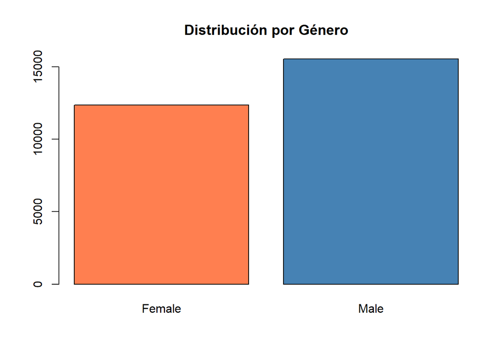

```r
barplot(table(data$Gender),
        main = "Distribución por Género",
        col = c("coral", "steelblue"))
```

El gráfico muestra una distribución relativamente balanceada (aunque puede haber ligera diferencia).

Por sí sola, esta variable no explica la depresión, pero es fundamental en análisis bivariados para detectar:

- diferencias en prevalencia
- vulnerabilidad diferencial

## Ciudad (City)

### Justificación

Puede capturar diferencias contextuales.

### Gráficos

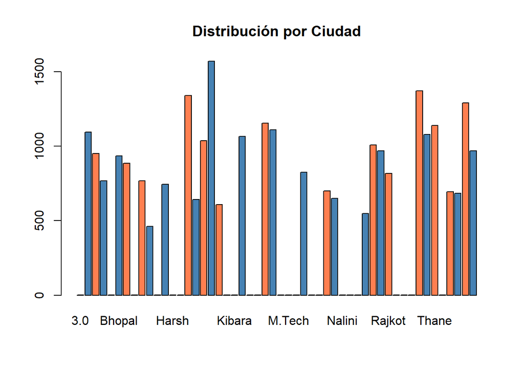

```r
barplot(table(data$City),
        main = "Distribución por Ciudad",
        col = c("coral", "steelblue"))
```

```r
length(unique(data$City))
```

```
## [1] 52
```

La alta cardinalidad (52 ciudades) dificulta su análisis univariado.

No es útil de forma individual, pero tiene alto valor si se:

- agrupa (por región, tamaño de ciudad)
- usa en modelos predictivos

Sin embargo para el caso de este analisis no se tendra en cuenta pues no parece tener una relacion con las causas de la depresion como otras variables

## Profesión (Profession)

### Gráficos

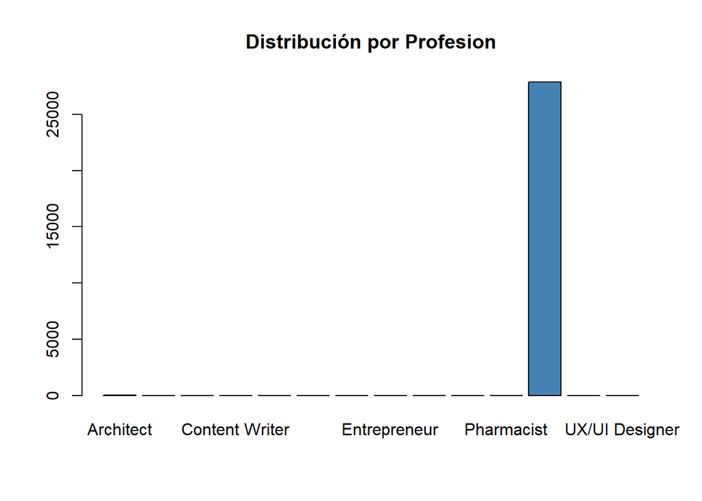

```r
barplot(table(data$Profession),
        main = "Distribución por Profesion",
        col = c("coral", "steelblue"))
```

```r
length(unique(data$Profession))
```

```
## [1] 14
```

Similar a ciudad, presenta muchas categorías. Su análisis univariado no es informativo, pero puede ser útil en reducción de dimensionalidad o agrupación.

## Duración del sueño (Sleep Duration)

### Gráficos

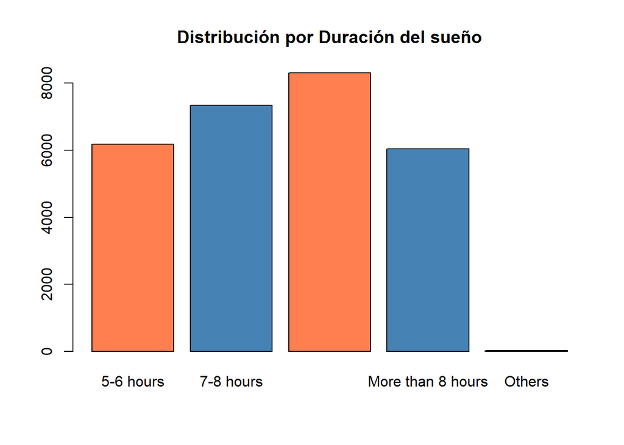

```r
barplot(table(data$Sleep.Duration),
        main = "Distribución por Duración del sueño",
        col = c("coral", "steelblue"))
```

Se observa predominancia menos de 5 horas, lo cual está por debajo del rango recomendado.

Esto evidencia un patrón preocupante: privación de sueño generalizada

Y esto está fuertemente relacionado con:

- ansiedad
- depresión
- bajo bienestar

## Hábitos alimenticios (Dietary Habits)

### Gráficos

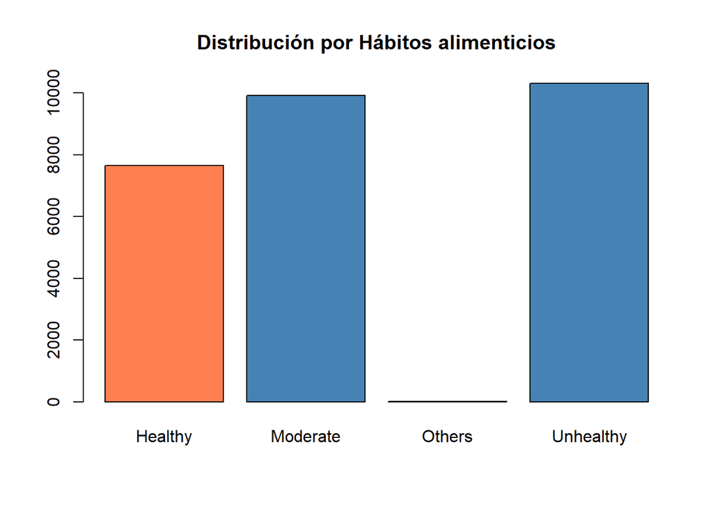

```r
barplot(table(data$Dietary.Habits),
        main = "Distribución por Hábitos alimenticios",
        col = c("coral", "steelblue"))
```

Más que un factor directo, parece actúar como indicador de: - estilo de vida desorganizado - posible falta de autocuidado

## Pensamientos suicidas

### Gráficos

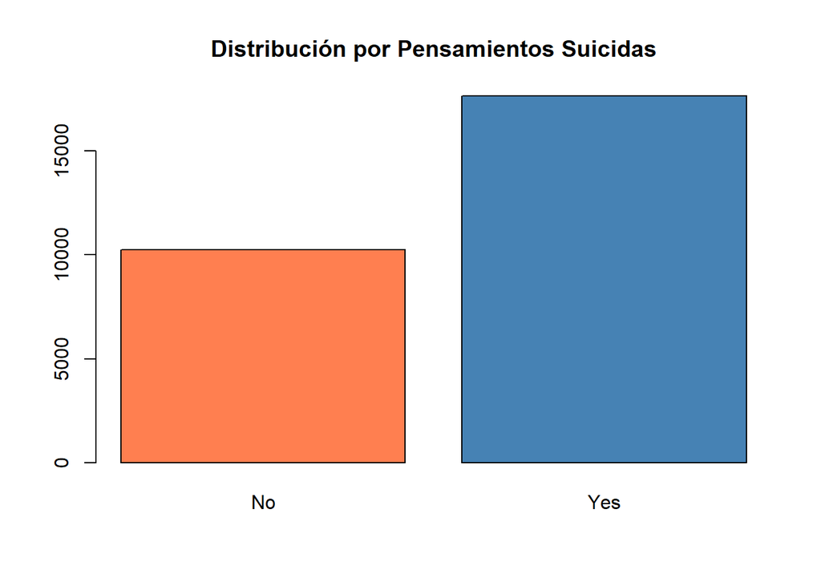

```r
barplot(table(data$Have.you.ever.had.suicidal.thoughts),
        main = "Distribución por Pensamientos Suicidas",
        col = c("coral", "steelblue"))
```

La presencia significativa de respuestas “Yes” indica una población con alto riesgo psicológico.

Esta es probablemente la variable más predictiva de depresión, y además:

- refleja gravedad del problema
- puede usarse como indicador temprano

## Historial familiar

### Gráficos

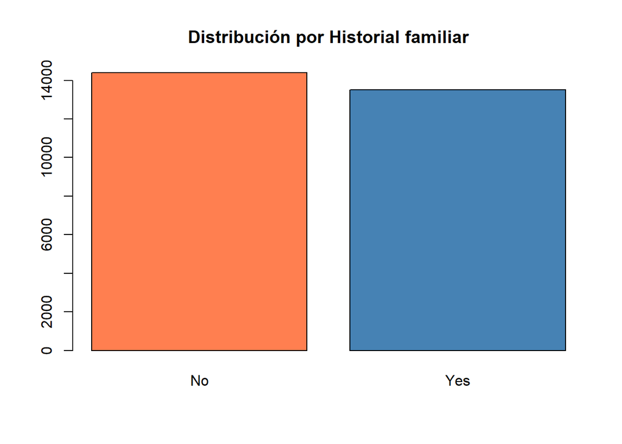

```r
barplot(table(data$Family.History.of.Mental.Illness),
        main = "Distribución por Historial familiar",
        col = c("coral", "steelblue"))
```

Existe una proporción importante de estudiantes con antecedentes familiares.

Este factor podria sugerir:

- predisposición genética
- influencia del entorno familiar

## Variable objetivo: Depresión

### Gráficos

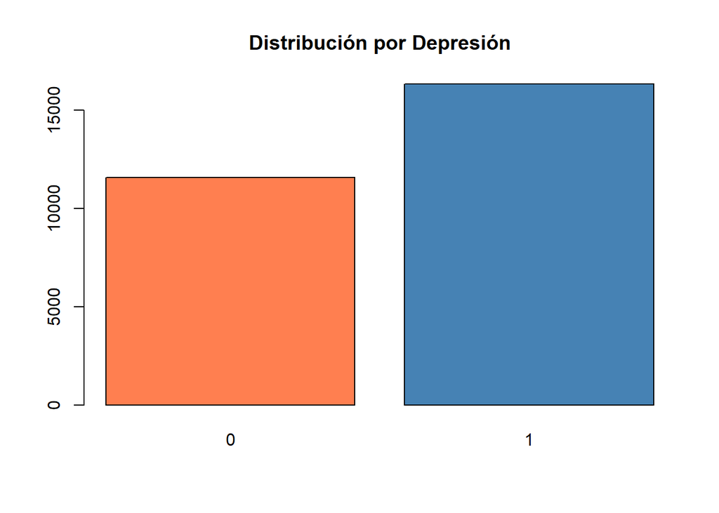

```r
barplot(table(data$Depression),
        main = "Distribución por Depresión",
        col = c("coral", "steelblue"))
```

Se observa una proporción de aproximadamente 58.5% con depresión, lo cual indica:

- el dataset está ligeramente desbalanceado hacia la clase positiva
- alta prevalencia del fenómeno
- No es un problema raro → es generalizado
- Se justifica completamente el análisis

# PARTE 3 - LIMPIEZA DE DATOS

## 1. Visualización dataset base

```r
head(data)
```

|  | id | Gender | Age | City | Profession | Academic.Pressure | Work.Pressure | CGPA | Study.Satisfaction | Job.Satisfaction | Sleep.Duration | Dietary.Habits | Degree | Have.you.ever.had.suicidal.thoughts.. | Work.Study.Hours | Financial.Stress | Family.History.of.Mental.Illness | Depression |
| --- | --- | --- | --- | --- | --- | --- | --- | --- | --- | --- | --- | --- | --- | --- | --- | --- | --- | --- |
| 1 | 2 | Male | 33 | Visakhapatnam | Student | 5 | 0 | 8.97 | 2 | 0 | 5-6 hours | Healthy | B.Pharm | Yes | 3 | 1 | No | 1 |
| 2 | 8 | Female | 24 | Bangalore | Student | 2 | 0 | 5.90 | 5 | 0 | 5-6 hours | Moderate | BSc | No | 3 | 2 | Yes | 0 |
| 3 | 26 | Male | 31 | Srinagar | Student | 3 | 0 | 7.03 | 5 | 0 | Less than 5 hours | Healthy | BA | No | 9 | 1 | Yes | 0 |
| 4 | 30 | Female | 28 | Varanasi | Student | 3 | 0 | 5.59 | 2 | 0 | 7-8 hours | Moderate | BCA | Yes | 4 | 5 | Yes | 1 |
| 5 | 32 | Female | 25 | Jaipur | Student | 4 | 0 | 8.13 | 3 | 0 | 5-6 hours | Moderate | M.Tech | Yes | 1 | 1 | No | 0 |
| 6 | 33 | Male | 29 | Pune | Student | 2 | 0 | 5.70 | 3 | 0 | Less than 5 hours | Healthy | PhD | No | 4 | 1 | No | 0 |

```r
str(data)
```

```
## 'data.frame':    27901 obs. of  18 variables:
##  $ id                                   : int  2 8 26 30 32 33 52 56 59 62 ...
##  $ Gender                               : chr  "Male" "Female" "Male" "Female" ...
##  $ Age                                  : num  33 24 31 28 25 29 30 30 28 31 ...
##  $ City                                 : chr  "Visakhapatnam" "Bangalore" "Srinagar" "Varanasi" ...
##  $ Profession                           : chr  "Student" "Student" "Student" "Student" ...
##  $ Academic.Pressure                    : num  5 2 3 3 4 2 3 2 3 2 ...
##  $ Work.Pressure                        : num  0 0 0 0 0 0 0 0 0 0 ...
##  $ CGPA                                 : num  8.97 5.9 7.03 5.59 8.13 5.7 9.54 8.04 9.79 8.38 ...
##  $ Study.Satisfaction                   : num  2 5 5 2 3 3 4 4 1 3 ...
##  $ Job.Satisfaction                     : num  0 0 0 0 0 0 0 0 0 0 ...
##  $ Sleep.Duration                       : chr  "5-6 hours" "5-6 hours" "Less than 5 hours" "7-8 hours" ...
##  $ Dietary.Habits                       : chr  "Healthy" "Moderate" "Healthy" "Moderate" ...
##  $ Degree                               : chr  "B.Pharm" "BSc" "BA" "BCA" ...
##  $ Have.you.ever.had.suicidal.thoughts..: chr  "Yes" "No" "No" "Yes" ...
##  $ Work.Study.Hours                     : num  3 3 9 4 1 4 1 0 12 2 ...
##  $ Financial.Stress                     : num  1 2 1 5 1 1 2 1 3 5 ...
##  $ Family.History.of.Mental.Illness     : chr  "No" "Yes" "Yes" "Yes" ...
##  $ Depression                           : int  1 0 0 1 0 0 0 0 1 1 ...
```

```r
summary(data)
```

```
##        id            Gender               Age            City
##  Min.   :     2   Length:27901       Min.   :18.00   Length:27901
##  1st Qu.: 35039   Class :character   1st Qu.:21.00   Class :character
##  Median : 70684   Mode  :character   Median :25.00   Mode  :character
##  Mean   : 70442                      Mean   :25.82
##  3rd Qu.:105818                      3rd Qu.:30.00
##  Max.   :140699                      Max.   :59.00
##
##   Profession        Academic.Pressure Work.Pressure            CGPA
##  Length:27901       Min.   :0.000     Min.   :0.0000000   Min.   : 0.000
##  Class :character   1st Qu.:2.000     1st Qu.:0.0000000   1st Qu.: 6.290
##  Mode  :character   Median :3.000     Median :0.0000000   Median : 7.770
##                     Mean   :3.141     Mean   :0.0004301   Mean   : 7.656
##                     3rd Qu.:4.000     3rd Qu.:0.0000000   3rd Qu.: 8.920
##                     Max.   :5.000     Max.   :5.0000000   Max.   :10.000
##
##  Study.Satisfaction Job.Satisfaction   Sleep.Duration     Dietary.Habits
##  Min.   :0.000      Min.   :0.000000   Length:27901       Length:27901
##  1st Qu.:2.000      1st Qu.:0.000000   Class :character   Class :character
##  Median :3.000      Median :0.000000   Mode  :character   Mode  :character
##  Mean   :2.944      Mean   :0.000681
##  3rd Qu.:4.000      3rd Qu.:0.000000
##  Max.   :5.000      Max.   :4.000000
##
##     Degree          Have.you.ever.had.suicidal.thoughts.. Work.Study.Hours
##  Length:27901       Length:27901                          Min.   : 0.000
##  Class :character   Class :character                      1st Qu.: 4.000
##  Mode  :character   Mode  :character                      Median : 8.000
##                                                           Mean   : 7.157
##                                                           3rd Qu.:10.000
##                                                           Max.   :12.000
##
##  Financial.Stress Family.History.of.Mental.Illness   Depression
##  Min.   :1.00     Length:27901                     Min.   :0.0000
##  1st Qu.:2.00     Class :character                 1st Qu.:0.0000
##  Median :3.00     Mode  :character                 Median :1.0000
##  Mean   :3.14                                      Mean   :0.5855
##  3rd Qu.:4.00                                      3rd Qu.:1.0000
##  Max.   :5.00                                      Max.   :1.0000
##  NA's   :3
```

```r
colSums(is.na(data))
```

```
##                                    id                                Gender
##                                     0                                     0
##                                   Age                                  City
##                                     0                                     0
##                            Profession                     Academic.Pressure
##                                     0                                     0
##                         Work.Pressure                                  CGPA
##                                     0                                     0
##                    Study.Satisfaction                      Job.Satisfaction
##                                     0                                     0
##                        Sleep.Duration                        Dietary.Habits
##                                     0                                     0
##                                Degree Have.you.ever.had.suicidal.thoughts..
##                                     0                                     0
##                      Work.Study.Hours                      Financial.Stress
##                                     0                                     3
##      Family.History.of.Mental.Illness                            Depression
##                                     0                                     0
```

### Interpretacion Inicial

La variable id no representa una característica propia de los individuos, sino únicamente un identificador de cada registro. Por esta razón, no aporta información relevante para el análisis y puede excluirse sin afectar la interpretación de los resultados.

La variable Age (Edad) presenta una media y una mediana muy cercanas, lo que sugiere una distribución aproximadamente simétrica. Además, los valores se encuentran entre los 18 y los 59 años, indicando que la muestra no está compuesta únicamente por estudiantes de pregrado, sino también por estudiantes de posgrado o personas que continúan sus estudios en etapas posteriores de la vida.

Las variables relacionadas con presión muestran resultados diferentes. Por un lado, Academic Pressure (Presión académica) se mide en una escala de 0 a 5 y tiene una media superior a 3, lo que evidencia que gran parte de los estudiantes percibe niveles relevantes de presión académica. Por otro lado, Work Pressure (Presión de trabajo) tiene una media de apenas 0.00043, es decir, prácticamente todos los registros toman el valor 0. Esto indica que la mayoría de los estudiantes no reporta presión laboral o no se encuentra trabajando, por lo que esta variable no aporta información importante para el objetivo del estudio.

De forma similar, las variables de satisfacción también presentan comportamientos contrastantes. La variable Study Satisfaction (Satisfacción con el estudio), medida en una escala de 0 a 5, tiene una media ligeramente inferior a 3. Esto representa una percepción neutral o levemente negativa hacia los estudios, lo que podría asociarse con falta de motivación, cansancio o desconexión académica. En contraste, Job Satisfaction (Satisfacción con el trabajo) tiene valores prácticamente nulos, al igual que la presión laboral, por lo que tampoco resulta útil dentro del análisis.

Respecto al desempeño académico, la variable CGPA (Rendimiento académico) presenta una media cercana a 8, lo que indica que, en general, los estudiantes tienen un buen rendimiento. Este resultado es importante porque sugiere que la presencia de depresión en la población no necesariamente está vinculada a un bajo promedio académico. Es decir, un estudiante puede tener un buen desempeño y aun así experimentar síntomas de depresión.

La variable Wor.Study.Hours (Horas de estudio/trabajo) tiene una media de 7.15 horas diarias y alcanza un máximo de 12 horas. Esto podría indicar que existe un grupo de estudiantes con una carga académica o laboral considerablemente alta, situación que puede favorecer el agotamiento, la fatiga o incluso el burnout.

Finalmente, la variable objetivo Depression (Depresión) está codificada como 0 para estudiantes sin depresión y 1 para estudiantes con depresión. Su media es de 0.5855, lo que permite interpretar que aproximadamente el 58.5 % de los estudiantes de la muestra presenta depresión. Este porcentaje es bastante alto y refuerza la importancia de analizar qué factores académicos, personales y económicos pueden estar influyendo en este fenómeno.

#### Variables categoricas

Estas variables representan el contexto social, los habitos y los factores psicologicos

- Gender
- City
- Profession
- Sleep.Duration
- Dietary.Habits
- Degree
- Suicidal thoughts
- Family history

## 2. Eliminacion de duplicados

Se eliminan registros duplicados para garantizar que cada observación represente un individuo único.

```r
data <- unique(data)
```

## 3. Correccion de tipos de datos

Se convierten variables categóricas a tipo factor para permitir su correcto análisis estadístico y visualización.

```r
# Convertir variables categóricas a factor
data$Gender <- as.factor(data$Gender)
data$City <- as.factor(data$City)
data$Profession <- as.factor(data$Profession)
data$Sleep.Duration <- as.factor(data$Sleep.Duration)
data$Dietary.Habits <- as.factor(data$Dietary.Habits)
data$Have.you.ever.had.suicidal.thoughts <- as.factor(data$Have.you.ever.had.suicidal.thoughts)
data$Family.History.of.Mental.Illness <- as.factor(data$Family.History.of.Mental.Illness)
data$Depression <- as.factor(data$Depression)
```

```r
data$ID <- NULL
```

# PARTE 4 - ANÁLISIS BIVARIADO

En esta sección se analizan las relaciones entre pares de variables, especialmente aquellas que potencialmente influyen en la depresión estudiantil. Se utilizan visualizaciones apropiadas según el tipo de variables involucradas.

## 4.1 Preparación de datos para análisis bivariado

```r
library(ggplot2)
library(dplyr)
# Crear factor de depresión para etiquetas consistentes
data$Depression_Factor <- factor(data$Depression,
                                  levels = c(0, 1),
                                  labels = c("Sin Depresión", "Con Depresión"))

# Transformar variables categóricas ordinales a numéricas para análisis
data_bivariado <- data %>%
  mutate(
    Sleep_Num = case_when(
      trimws(Sleep.Duration) == "Less than 5 hours" ~ 0,
      trimws(Sleep.Duration) == "5-6 hours" ~ 1,
      trimws(Sleep.Duration) == "7-8 hours" ~ 2,
      trimws(Sleep.Duration) == "More than 8 hours" ~ 3,
      TRUE ~ NA_real_
    ),
    Diet_Num = case_when(
      trimws(Dietary.Habits) == "Unhealthy" ~ 0,
      trimws(Dietary.Habits) == "Moderate" ~ 1,
      trimws(Dietary.Habits) == "Healthy" ~ 2,
      TRUE ~ NA_real_
    ),
    Suicidal_Num = case_when(
      Have.you.ever.had.suicidal.thoughts == "No" ~ 0,
      Have.you.ever.had.suicidal.thoughts == "Yes" ~ 1,
      TRUE ~ NA_real_
    ),
    Family_History_Num = case_when(
      Family.History.of.Mental.Illness == "No" ~ 0,
      Family.History.of.Mental.Illness == "Yes" ~ 1,
      TRUE ~ NA_real_
    )
  ) %>%
  filter(!is.na(Sleep_Num), !is.na(Diet_Num))  # Eliminar "Others" de estas variables
```

## 4.2 Estrés financiero vs Depresión

**Tipo de análisis:** Categórica (Depresión) vs Numérica (Estrés Financiero)  
**Gráfico:** Boxplot

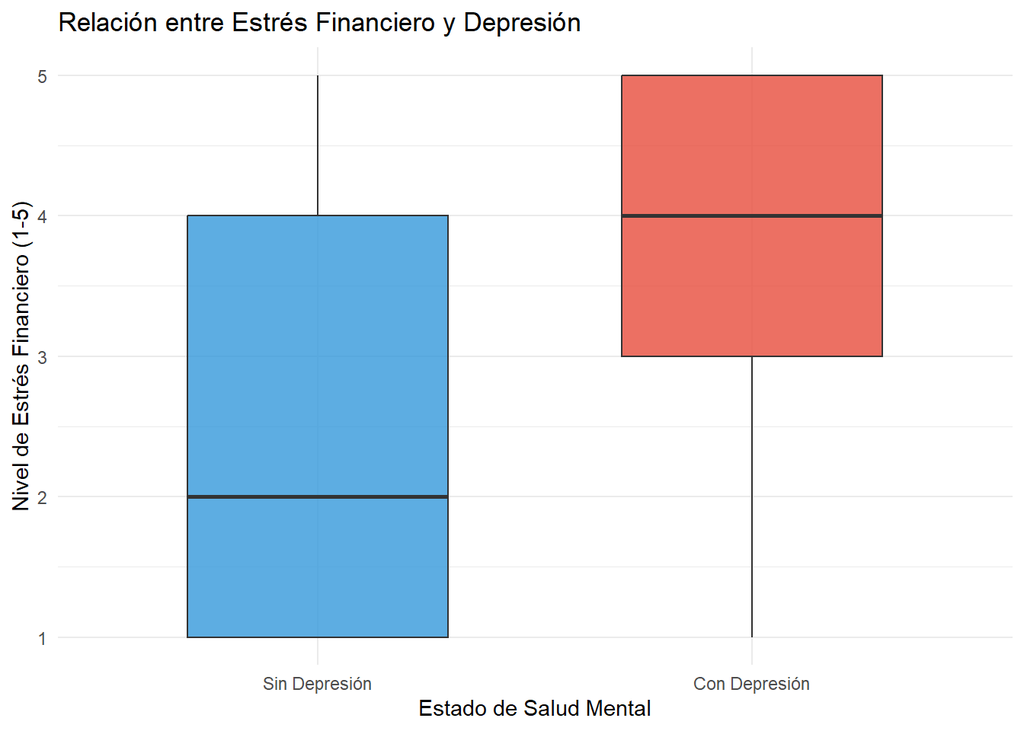

```r
ggplot(data_bivariado, aes(x = Depression_Factor, y = Financial.Stress, fill = Depression_Factor)) +
  geom_boxplot(width = 0.6, alpha = 0.8) +
  scale_fill_manual(values = c("#3498db", "#e74c3c")) +
  labs(
    title = "Relación entre Estrés Financiero y Depresión",
    x = "Estado de Salud Mental",
    y = "Nivel de Estrés Financiero (1-5)"
  ) +
  theme_minimal() +
  theme(legend.position = "none")
```

## 4.3 Horas de estudio/trabajo vs Depresión

**Tipo de análisis:** Categórica (Depresión) vs Numérica (Horas) **Gráfico:** Boxplot

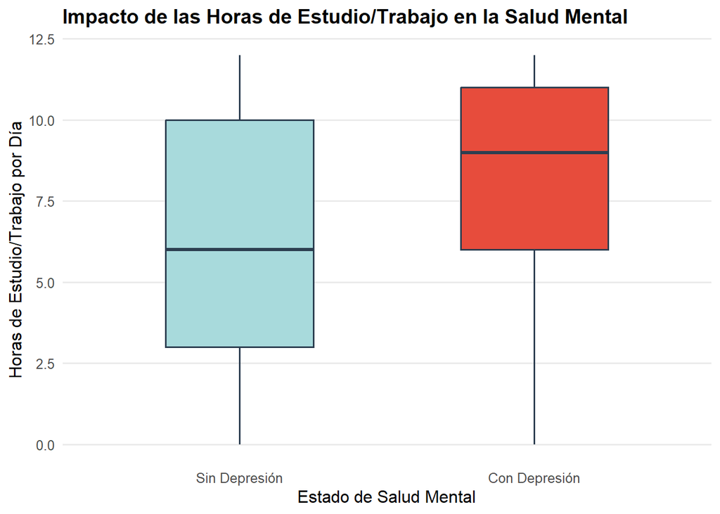

```r
ggplot(data_bivariado, aes(x = Depression_Factor, y = Work.Study.Hours, fill = Depression_Factor)) +
  geom_boxplot(width = 0.5, outlier.shape = 16, outlier.size = 1.5,
               outlier.alpha = 0.5, color = "#2c3e50") +
  labs(
    title = "Impacto de las Horas de Estudio/Trabajo en la Salud Mental",
    x = "Estado de Salud Mental",
    y = "Horas de Estudio/Trabajo por Día"
  ) +
  scale_fill_manual(values = c("#A8DADC", "#e74c3c")) +
  theme_minimal(base_size = 12) +
  theme(
    legend.position = "none",
    plot.title = element_text(face = "bold", size = 14),
    panel.grid.minor = element_blank(),
    panel.grid.major.x = element_blank()
  )
```

## 4.4 Hábitos alimenticios vs Depresión

**Tipo de análisis:** Categórica ordinal vs Categórica nominal **Gráfico:** Barras agrupadas (dodge)

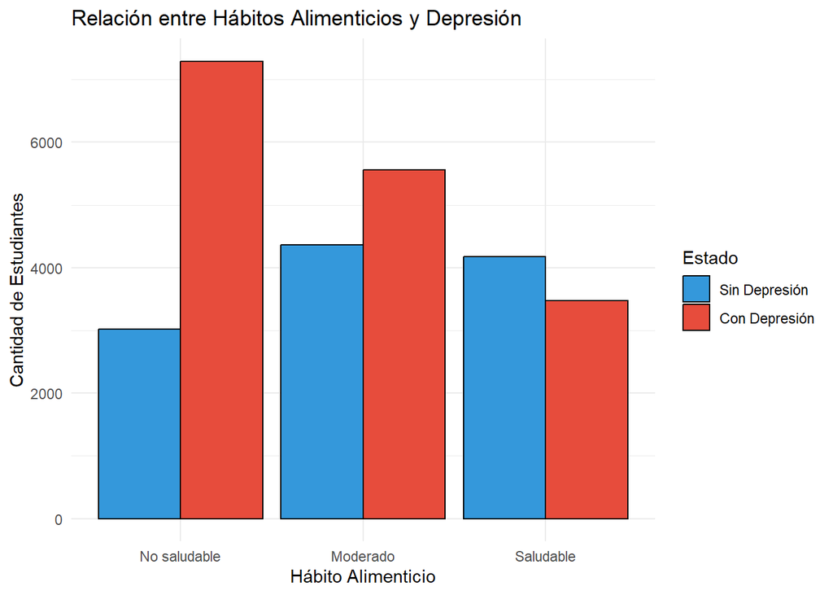

```r
ggplot(data_bivariado, aes(x = factor(Diet_Num), fill = Depression_Factor)) +
  geom_bar(position = "dodge", color = "black") +
  scale_x_discrete(labels = c("0" = "No saludable", "1" = "Moderado", "2" = "Saludable")) +
  scale_fill_manual(values = c("#3498db", "#e74c3c")) +
  labs(
    title = "Relación entre Hábitos Alimenticios y Depresión",
    x = "Hábito Alimenticio",
    y = "Cantidad de Estudiantes",
    fill = "Estado"
  ) +
  theme_minimal()
```

- **Interpretación**: En la gráfica de barras doble se puede ver qué en las barras de personas que tienen una dieta saludable hay más personas sin depresión, aunque la diferencia no es muy grande. En los otros 2 rangos menos saludables existe mayor presencia de gente con depresión, pero hay una mayor diferencia entre la cantidad con depresión que con la que no tiene depresión en la dieta no saludable.
- **Conclusión**: Se puede ver cómo entre menos saludable es la dieta hay una mayor presencia de personas con depresión.

## 4.5 Presión académica vs Depresión

**Tipo de análisis:** Categórica (Depresión) vs Numérica ordinal **Gráfico:** Boxplot

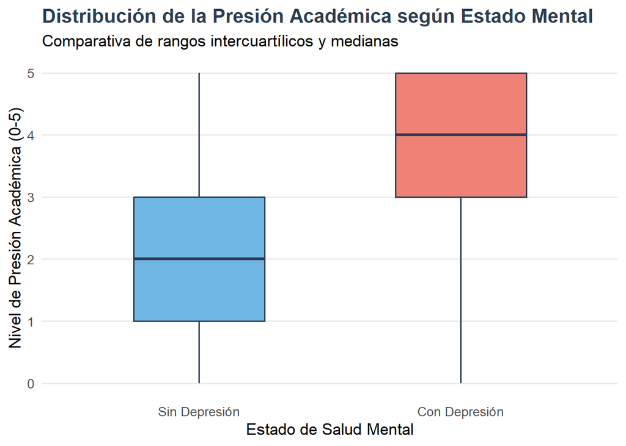

```r
ggplot(data_bivariado, aes(x = Depression_Factor, y = Academic.Pressure, fill = Depression_Factor)) +
  geom_boxplot(width = 0.5, outlier.colour = "#e74c3c", outlier.shape = 16,
               outlier.size = 2, alpha = 0.7, color = "#2c3e50") +
  scale_fill_manual(values = c("#3498db", "#e74c3c")) +
  labs(
    title = "Distribución de la Presión Académica según Estado Mental",
    subtitle = "Comparativa de rangos intercuartílicos y medianas",
    x = "Estado de Salud Mental",
    y = "Nivel de Presión Académica (0-5)"
  ) +
  theme_minimal(base_size = 13) +
  theme(
    legend.position = "none",
    plot.title = element_text(face = "bold", color = "#2c3e50"),
    panel.grid.minor = element_blank(),
    panel.grid.major.x = element_blank()
  )
```

- **Interpretación**: los rangos que se manejan son casi completamente distintos,es un factor diferenciador, las medianas están separadas por dos puntos en la escala de presión academica, el rango intercuartilico es el mismo para ambos.
- **Conclusión**: el nivel de presión academico es un factor que separa a ambos grupos( los que tienen y no tienen depresión), la mediana de cada grupo está muy alejada, además de estar uniformemente en el centro, una presión academica puede ser un factor que genere depresión según el gráfico.

## 4.6 Duración del sueño vs Depresión

**Tipo de análisis:** Categórica ordinal vs Categórica nominal **Gráfico:** Barras agrupadas (dodge)

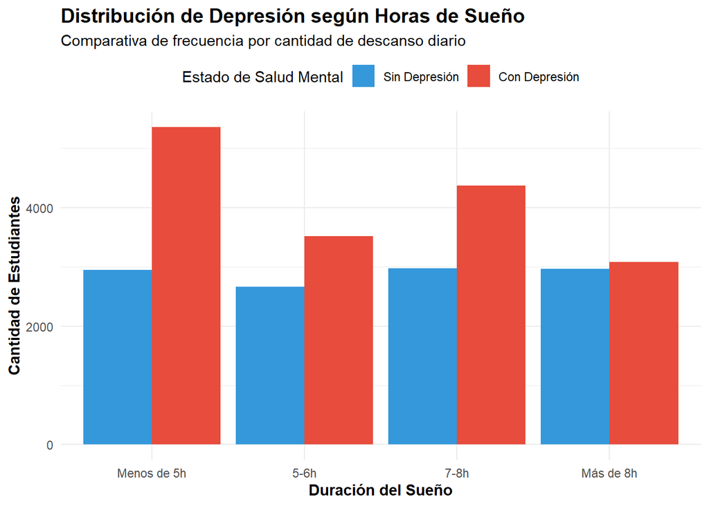

```r
data_bivariado$Sleep_Grafico <- factor(data_bivariado$Sleep_Num,
                                        levels = c(0, 1, 2, 3),
                                        labels = c("Menos de 5h", "5-6h", "7-8h", "Más de 8h"))

ggplot(data_bivariado, aes(x = Sleep_Grafico, fill = Depression_Factor)) +
  geom_bar(position = "dodge") +
  scale_fill_manual(values = c("#3498db", "#e74c3c")) +
  labs(
    title = "Distribución de Depresión según Horas de Sueño",
    subtitle = "Comparativa de frecuencia por cantidad de descanso diario",
    x = "Duración del Sueño",
    y = "Cantidad de Estudiantes",
    fill = "Estado de Salud Mental"
  ) +
  theme_minimal() +
  theme(
    plot.title = element_text(face = "bold", size = 14),
    axis.title = element_text(face = "bold"),
    legend.position = "top"
  )
```

# PARTE 6. Análisis Multivariado Básico

## Matriz de Correlación

```r
library(dplyr)
data_num <- data %>%
  mutate(
    Sleep_Num = case_when(
      trimws(Sleep.Duration) == "Less than 5 hours" ~ 4,
      trimws(Sleep.Duration) == "5-6 hours" ~ 5.5,
      trimws(Sleep.Duration) == "7-8 hours" ~ 7.5,
      trimws(Sleep.Duration) == "More than 8 hours" ~ 9,
      TRUE ~ NA_real_
    ),
    Diet_Num = case_when(
      trimws(Dietary.Habits) == "Unhealthy" ~ 1,
      trimws(Dietary.Habits) == "Moderate" ~ 2,
      trimws(Dietary.Habits) == "Healthy" ~ 3,
      TRUE ~ NA_real_
    ),
    Depression_num = as.numeric(as.character(Depression)),

    Suicidal_Num = ifelse(trimws(Have.you.ever.had.suicidal.thoughts) == "Yes", 1, 0),
    Family_History_Num = ifelse(trimws(Family.History.of.Mental.Illness) == "Yes", 1, 0)
  ) %>%

  select(Age, Academic.Pressure, CGPA, Study.Satisfaction,
         Work.Study.Hours,
         Sleep_Num, Diet_Num, Financial.Stress,
         Suicidal_Num, Family_History_Num,
         Depression_num, Depression) %>%
  na.omit()
```

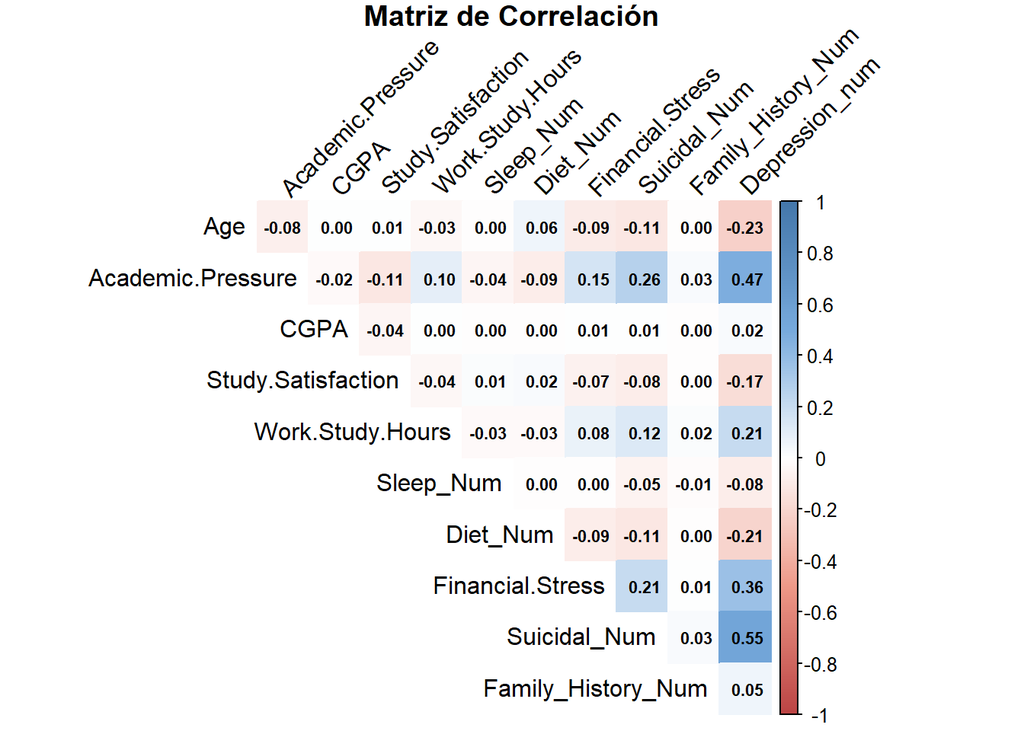

```r
library(corrplot)
matriz_cor <- cor(data_num %>% select(-Depression))

# Crear una paleta de colores
colores <- colorRampPalette(c("#BB4444", "#EE9988", "#FFFFFF", "#77AADD", "#4477AA"))

# Graficar ocultando la diagonal para que se vea más limpio
corrplot(matriz_cor, method = "color", type = "upper",
         col = colores(200),
         tl.col = "black", tl.srt = 45,
         addCoef.col = "black", number.cex = 0.7,
         diag = FALSE,
         title = "Matriz de Correlación", mar=c(0,0,1,0))
```

### ¿Qué variables están mas relacionadas?

La variable objetivo, ``Depression`, tiene una fuerte correlación positiva con `Academic.Pressure` (0.47) y `Financial.Stress` (0.36). Es decir, a mayor presión académica y estrés financiero, mayor probabilidad de depresión. Curiosamente, tiene una correlación negativa con `Age` (-0.23), sugiriendo que los estudiantes más jóvenes del dataset son más propensos a la depresión. Un hallazgo clave es que el `CGPA` (promedio de notas) no tiene relación alguna con la depresión (0.02). Como podría ser intuitivo, la relación más fuerte se encuentra con `Suicidal.Thoughts` (0.55), demostrando la alta relación que hay entre los pensamientos suicidas y la depresión, siendo una relación predecible a nivel intuitivo, aunque dificil de decir si los pensamientos suicidas son causa de la depresión o una consecuencia, pero lo cierto es que estan muy correlacionadas.

## ¿Qué patrones globales se observan?

Se observa que el estrés financiero y la presión académica se mueven en la misma dirección (tienen una correlación positiva entre sí del 0.15). El patrón global indica que la depresión estudiantil en este dataset es un problema impulsado por factores de carga mental y económica, más que por el rendimiento académico numérico (notas).

## Coordenadas Paralelas

```r
# library(GGally)
#
# # 1. Creamos una columna temporal como factor para los colores
# data_num$Depression_Factor <- as.factor(data_num$Depression_num)
#
# # 2. Generamos el gráfico
# ggparcoord(data = data_num,
#            columns = 1:10,
#            groupColumn = "Depression_Factor",
#            scale = "std",
#            alphaLines = 0.05) +
#   scale_color_manual(values = c("0" = "#1f77b4", "1" = "#d62728")) +
#   theme_minimal() +
#   labs(title = "Coordenadas Paralelas (Agrupadas por Depresión)",
#        x = "Variables", y = "Valor Estandarizado") +
#   theme(axis.text.x = element_text(angle = 45, hjust = 1))
#
# # 3. Borramos la columna temporal para que no afecte la Parte 7 (Medidas descriptivas)
# data_num$Depression_Factor <- NULL
```

### ¿Existen grupos de observaciones similares?

# PARTE 7. Medidas descriptivas multivariantes

## Media Vectorial

```r
library(dplyr)
# Comparación de vectores de medias por grupo de depresión
tabla_centroides <- data_num %>%
  group_by(Depression_num) %>%
  summarise(across(where(is.numeric), mean)) %>%
  print(width = Inf)
```

```
## # A tibble: 2 × 11
##   Depression_num   Age Academic.Pressure  CGPA Study.Satisfaction
##            <dbl> <dbl>             <dbl> <dbl>              <dbl>
## 1              0  27.1              2.36  7.62               3.22
## 2              1  24.9              3.69  7.68               2.75
##   Work.Study.Hours Sleep_Num Diet_Num Financial.Stress Suicidal_Num
##              <dbl>     <dbl>    <dbl>            <dbl>        <dbl>
## 1             6.24      6.53     2.10             2.52        0.320
## 2             7.81      6.20     1.77             3.58        0.854
##   Family_History_Num
##                <dbl>
## 1              0.452
## 2              0.506
```

### Reafirmación de hallazgos anteriores

Observamos un desplazamiento sistemático hacia valores más altos en los factores estresores para el grupo con depresión: * Presión Académica: Aumenta de 2.36 a 3.69. * Horas de Trabajo/Estudio: Sube de 6.24 a 7.81 horas diarias. * Estrés Financiero: Se eleva de 2.52 a 3.58.

El estudiante deprimido promedio vive en un estado de “sobrecarga”. No solo percibe más presión, sino que objetivamente dedica más horas al día a sus responsabilidades, lo que reduce su margen de recuperación.

En el vector del grupo con depresión, las variables de bienestar muestran una caída:

*Sueño (Sleep_Num): Cae de 6.53 a 6.20.* Dieta (Diet_Num): Disminuye de 2.10 a 1.77.

Aunque la diferencia en horas de sueño parece pequeña, en términos poblacionales indica una tendencia a la privación crónica. Junto con una peor calidad de dieta, el centroide del grupo con depresión refleja un abandono de los hábitos biológicos básicos.

## Dispersión

```r
matriz_cov <- cov(data_num %>% select(where(is.numeric)))
print("--- Matriz de Varianza-Covarianza ---")
```

```
## [1] "--- Matriz de Varianza-Covarianza ---"
```

```r
print(round(matriz_cov, 2))
```

```
##                      Age Academic.Pressure  CGPA Study.Satisfaction
## Age                24.07             -0.52  0.04               0.06
## Academic.Pressure  -0.52              1.91 -0.05              -0.21
## CGPA                0.04             -0.05  2.16              -0.09
## Study.Satisfaction  0.06             -0.21 -0.09               1.85
## Work.Study.Hours   -0.60              0.49  0.02              -0.18
## Sleep_Num          -0.04             -0.11 -0.01               0.03
## Diet_Num            0.23             -0.10  0.00               0.02
## Financial.Stress   -0.67              0.30  0.01              -0.13
## Suicidal_Num       -0.27              0.17  0.01              -0.05
## Family_History_Num -0.01              0.02  0.00               0.00
## Depression_num     -0.55              0.32  0.02              -0.11
##                    Work.Study.Hours Sleep_Num Diet_Num Financial.Stress
## Age                           -0.60     -0.04     0.23            -0.67
## Academic.Pressure              0.49     -0.11    -0.10             0.30
## CGPA                           0.02     -0.01     0.00             0.01
## Study.Satisfaction            -0.18      0.03     0.02            -0.13
## Work.Study.Hours              13.74     -0.20    -0.09             0.40
## Sleep_Num                     -0.20      3.68     0.00            -0.01
## Diet_Num                      -0.09      0.00     0.64            -0.10
## Financial.Stress               0.40     -0.01    -0.10             2.07
## Suicidal_Num                   0.22     -0.05    -0.04             0.14
## Family_History_Num             0.03     -0.01     0.00             0.01
## Depression_num                 0.38     -0.08    -0.08             0.26
##                    Suicidal_Num Family_History_Num Depression_num
## Age                       -0.27              -0.01          -0.55
## Academic.Pressure          0.17               0.02           0.32
## CGPA                       0.01               0.00           0.02
## Study.Satisfaction        -0.05               0.00          -0.11
## Work.Study.Hours           0.22               0.03           0.38
## Sleep_Num                 -0.05              -0.01          -0.08
## Diet_Num                  -0.04               0.00          -0.08
## Financial.Stress           0.14               0.01           0.26
## Suicidal_Num               0.23               0.01           0.13
## Family_History_Num         0.01               0.25           0.01
## Depression_num             0.13               0.01           0.24
```

### ¿Qué tan dispersos están los datos?

Se pueden encontrar covarianzas conjuntas críticas: la relación entre Work.Study.Hours y Academic.Pressure (0.49) confirma que la carga horaria no es solo fatiga física, sino que crece de la mano con la presión psicológica. Asimismo, la covarianza positiva entre Financial.Stress y Academic.Pressure (0.30) sugiere que las tensiones económicas y académicas no vienen solas; suelen presentarse como un bloque de presión acumulada que aumenta la dispersión del bienestar del estudiante.

```r
# Extraemos solo las varianzas (la diagonal de la matriz)
varianzas <- diag(matriz_cov)
print("--- Varianzas individuales (Qué variables fluctúan más) ---")
```

```
## [1] "--- Varianzas individuales (Qué variables fluctúan más) ---"
```

```r
print(round(sort(varianzas, decreasing = TRUE), 2))
```

```
##                Age   Work.Study.Hours          Sleep_Num               CGPA
##              24.07              13.74               3.68               2.16
##   Financial.Stress  Academic.Pressure Study.Satisfaction           Diet_Num
##               2.07               1.91               1.85               0.64
## Family_History_Num     Depression_num       Suicidal_Num
##               0.25               0.24               0.23
```

### ¿Qué variables varían más?

Observando las varianzas individuales (la diagonal principal), `Age` (24.07) y `Work.Study.Hours` (13.75) son las que más fluctúan. Sin embargo, cabe aclarar que esto se debe a la escala de medida. La edad se mide en años y las horas de trabajo van en un rango amplio, mientras que variables como `Study.Satisfaction` o `Financial.Stress` se mueven en escalas mucho más pequeñas (ej. de 1 a 5), por lo que su varianza matemática siempre será menor (alrededor de 1.8 a 2.0).

## Dependencia

```r
print("--- Dependencia (Correlación) ---")
```

```
## [1] "--- Dependencia (Correlación) ---"
```

```r
print(round(matriz_cor, 2))
```

```
##                      Age Academic.Pressure  CGPA Study.Satisfaction
## Age                 1.00             -0.08  0.00               0.01
## Academic.Pressure  -0.08              1.00 -0.02              -0.11
## CGPA                0.00             -0.02  1.00              -0.04
## Study.Satisfaction  0.01             -0.11 -0.04               1.00
## Work.Study.Hours   -0.03              0.10  0.00              -0.04
## Sleep_Num           0.00             -0.04  0.00               0.01
## Diet_Num            0.06             -0.09  0.00               0.02
## Financial.Stress   -0.09              0.15  0.01              -0.07
## Suicidal_Num       -0.11              0.26  0.01              -0.08
## Family_History_Num  0.00              0.03  0.00               0.00
## Depression_num     -0.23              0.47  0.02              -0.17
##                    Work.Study.Hours Sleep_Num Diet_Num Financial.Stress
## Age                           -0.03      0.00     0.06            -0.09
## Academic.Pressure              0.10     -0.04    -0.09             0.15
## CGPA                           0.00      0.00     0.00             0.01
## Study.Satisfaction            -0.04      0.01     0.02            -0.07
## Work.Study.Hours               1.00     -0.03    -0.03             0.08
## Sleep_Num                     -0.03      1.00     0.00             0.00
## Diet_Num                      -0.03      0.00     1.00            -0.09
## Financial.Stress               0.08      0.00    -0.09             1.00
## Suicidal_Num                   0.12     -0.05    -0.11             0.21
## Family_History_Num             0.02     -0.01     0.00             0.01
## Depression_num                 0.21     -0.08    -0.21             0.36
##                    Suicidal_Num Family_History_Num Depression_num
## Age                       -0.11               0.00          -0.23
## Academic.Pressure          0.26               0.03           0.47
## CGPA                       0.01               0.00           0.02
## Study.Satisfaction        -0.08               0.00          -0.17
## Work.Study.Hours           0.12               0.02           0.21
## Sleep_Num                 -0.05              -0.01          -0.08
## Diet_Num                  -0.11               0.00          -0.21
## Financial.Stress           0.21               0.01           0.36
## Suicidal_Num               1.00               0.03           0.55
## Family_History_Num         0.03               1.00           0.05
## Depression_num             0.55               0.05           1.00
```

### ¿Cómo se relacionan entre sí?

La relación más alarmante es la de Suicidal_Num con Depression_num (0.55). Esta es la correlación más alta de todo el estudio, indicando que la depresión en esta muestra está vinculada de manera casi intrínseca a un riesgo de vida.

Por otro lado, la Presión Académica (0.47) y el Estrés Financiero (0.36) emergen como los dos motores externos más fuertes de la depresión. Es notable que el CGPA (0.02) prácticamente no tiene relación con el estado depresivo, lo que rompe el mito de que el buen rendimiento protege la salud mental. Finalmente, observamos una correlación negativa importante entre los Hábitos Alimenticios (Diet_Num) y la Depresión (-0.21), lo que sugiere que el deterioro de la salud física y la falta de autocuidado son señales tempranas del colapso emocional.

# PARTE 9: PCA

```r
# LIBRERÍAS

library(MVN)        # Para normalidad multivariante
library(car)        # Para elipses de confianza y covarianza
library(factoextra) # Para visualizar el PCA
library(FactoMineR) # Para hacer el PCA

# Cargamos los datos numéricos en una nueva variable para el PCA (se excluye el target)
data_pca <- data_num[, c("Age", "Academic.Pressure", "Work.Study.Hours",
                         "Financial.Stress", "Sleep_Num", "CGPA", "Suicidal_Num")]
```

## Normalidad Multivariante

```r
resultado_mardia <- mardia(data_pca)
print(resultado_mardia)
```

```
##              Test  Statistic p.value     Method
## 1 Mardia Skewness 2807.47929       0 asymptotic
## 2 Mardia Kurtosis  -57.91763       0 asymptotic
```

## Nube de datos

Nubes de datos de las variables más correlacionadas.

```r
g_age_suicidal <- ggplot(data_pca, aes(Age, Suicidal_Num)) +
  geom_point(alpha = 0.45, size = 1.6) +
  stat_ellipse(type = "norm", linewidth = 1.1) +
  coord_equal() +
  labs(
    title = "Nube de datos (Age y Suicidal_num)",
    subtitle = "La elipse muestra una dirección natural de máxima variabilidad",
    x = "Age",
    y = "Suicidal_num"
  ) +
  theme_minimal(base_size = 13)

plotly::ggplotly(g_age_suicidal)
```

[interactive chart not shown]

```r
g_academic_financial <- ggplot(data_pca, aes(Academic.Pressure, Financial.Stress)) +
  geom_point(alpha = 0.45, size = 1.6) +
  stat_ellipse(type = "norm", linewidth = 1.1) +
  coord_equal() +
  labs(
    title = "Nube de datos (Academic.Pressure y Financial.Stress)",
    subtitle = "La elipse muestra una dirección natural de máxima variabilidad",
    x = "Academic.Pressure",
    y = " Financial.Stresss"
  ) +
  theme_minimal(base_size = 13)

plotly::ggplotly(g_academic_financial)
```

[interactive chart not shown]

```r
g_academic_suicidal <- ggplot(data_pca, aes(Academic.Pressure, Suicidal_Num)) +
  geom_point(alpha = 0.45, size = 1.6) +
  stat_ellipse(type = "norm", linewidth = 1.1) +
  coord_equal() +
  labs(
    title = "Nube de datos (Academic.Pressure y Suicidal_num)",
    subtitle = "La elipse muestra una dirección natural de máxima variabilidad",
    x = "Academic.Pressure",
    y = "Suicidal_num"
  ) +
  theme_minimal(base_size = 13)

plotly::ggplotly(g_academic_suicidal)
```

[interactive chart not shown]

```r
g_work_suicidal <- ggplot(data_pca, aes(Work.Study.Hours, Suicidal_Num)) +
  geom_point(alpha = 0.45, size = 1.6) +
  stat_ellipse(type = "norm", linewidth = 1.1) +
  coord_equal() +
  labs(
    title = "Nube de datos (Work.Study.Hours y Suicidal_num)",
    subtitle = "La elipse muestra una dirección natural de máxima variabilidad",
    x = "Work.Study.Hours",
    y = "Suicidal_num"
  ) +
  theme_minimal(base_size = 13)

plotly::ggplotly(g_work_suicidal)
```

[interactive chart not shown]

```r
g_financial_suicidal <- ggplot(data_pca, aes(Financial.Stress, Suicidal_Num)) +
  geom_point(alpha = 0.45, size = 1.6) +
  stat_ellipse(type = "norm", linewidth = 1.1) +
  coord_equal() +
  labs(
    title = "Nube de datos (Financial.Stress y Suicidal_num)",
    subtitle = "La elipse muestra una dirección natural de máxima variabilidad",
    x = "Financial.Stress",
    y = "Suicidal_num"
  ) +
  theme_minimal(base_size = 13)

plotly::ggplotly(g_financial_suicidal)
```

[interactive chart not shown]

### Resultados

Al realizar las nubes de datos de las variables más correlacionadas se puede observar que gráficos como:

- “Age vs suicidal_num”y “Work.study.hours vs suicidal_num” tienen una nube horizontal que no muestra una variación, entonces no sirven para reducir dimensionalidad ya que las variables como Suicidal_num son casi contantes por su poca escala .
- En “financial Stress vs Academic pressure por su forma casi circular sugiere una correlación baja que no aporta al análisis.
- “Academic.Pressure y Suicidal_num” y “Financial.Stress y Suicidal_num” se puede ver una elipse con una ligera inclinación positiva que podría ser engañosa pero no existe una correlación lineal significativa que sustente su uso.

## Estandarización

```r
summary(data_pca)
```

```
##       Age        Academic.Pressure Work.Study.Hours Financial.Stress
##  Min.   :18.00   Min.   :0.000     Min.   : 0.000   Min.   :1.00
##  1st Qu.:21.00   1st Qu.:2.000     1st Qu.: 4.000   1st Qu.:2.00
##  Median :25.00   Median :3.000     Median : 8.000   Median :3.00
##  Mean   :25.82   Mean   :3.141     Mean   : 7.158   Mean   :3.14
##  3rd Qu.:30.00   3rd Qu.:4.000     3rd Qu.:10.000   3rd Qu.:4.00
##  Max.   :59.00   Max.   :5.000     Max.   :12.000   Max.   :5.00
##    Sleep_Num          CGPA         Suicidal_Num
##  Min.   :4.000   Min.   : 0.000   Min.   :0.0000
##  1st Qu.:4.000   1st Qu.: 6.290   1st Qu.:0.0000
##  Median :5.500   Median : 7.770   Median :1.0000
##  Mean   :6.339   Mean   : 7.656   Mean   :0.6328
##  3rd Qu.:7.500   3rd Qu.: 8.920   3rd Qu.:1.0000
##  Max.   :9.000   Max.   :10.000   Max.   :1.0000
```

```r
data_pca <- as.data.frame(scale(data_pca))
summary(data_pca)
```

```
##       Age          Academic.Pressure Work.Study.Hours  Financial.Stress
##  Min.   :-1.5943   Min.   :-2.2737   Min.   :-1.9308   Min.   :-1.48904
##  1st Qu.:-0.9827   1st Qu.:-0.8261   1st Qu.:-0.8518   1st Qu.:-0.79328
##  Median :-0.1673   Median :-0.1023   Median : 0.2271   Median :-0.09752
##  Mean   : 0.0000   Mean   : 0.0000   Mean   : 0.0000   Mean   : 0.00000
##  3rd Qu.: 0.8519   3rd Qu.: 0.6215   3rd Qu.: 0.7666   3rd Qu.: 0.59824
##  Max.   : 6.7633   Max.   : 1.3453   Max.   : 1.3061   Max.   : 1.29400
##    Sleep_Num            CGPA           Suicidal_Num
##  Min.   :-1.2198   Min.   :-5.20599   Min.   :-1.3127
##  1st Qu.:-1.2198   1st Qu.:-0.92900   1st Qu.:-1.3127
##  Median :-0.4375   Median : 0.07734   Median : 0.7617
##  Mean   : 0.0000   Mean   : 0.00000   Mean   : 0.0000
##  3rd Qu.: 0.6055   3rd Qu.: 0.85930   3rd Qu.: 0.7617
##  Max.   : 1.3877   Max.   : 1.59367   Max.   : 0.7617
```

## Autovalores y Autovectores

```r
S <- cov(data_pca)
eig <- eigen(S)

var_exp <- eig$values / sum(eig$values)

data.frame(
  Componente = paste0("PC", seq_along(eig$values)),
  Autovalor = eig$values,
  Varianza_Explicada = var_exp,
  Varianza_Acumulada = cumsum(var_exp)
)
```

| Componente | Autovalor | Varianza_Explicada | Varianza_Acumulada |
| --- | --- | --- | --- |
| PC1 | 1.5385345 | 0.2197906 | 0.2197906 |
| PC2 | 1.0158030 | 0.1451147 | 0.3649054 |
| PC3 | 1.0017338 | 0.1431048 | 0.5080102 |
| PC4 | 0.9551949 | 0.1364564 | 0.6444666 |
| PC5 | 0.9212756 | 0.1316108 | 0.7760774 |
| PC6 | 0.8443530 | 0.1206219 | 0.8966993 |
| PC7 | 0.7231051 | 0.1033007 | 1.0000000 |

## Análisis de Componentes Principales (PCA)

```r
pca <- prcomp(data_pca, center = TRUE, scale. = TRUE)

summary(pca)
```

```
## Importance of components:
##                           PC1    PC2    PC3    PC4    PC5    PC6    PC7
## Standard deviation     1.2404 1.0079 1.0009 0.9773 0.9598 0.9189 0.8504
## Proportion of Variance 0.2198 0.1451 0.1431 0.1365 0.1316 0.1206 0.1033
## Cumulative Proportion  0.2198 0.3649 0.5080 0.6445 0.7761 0.8967 1.0000
```

```r
var <- (pca$sdev^2) / sum(pca$sdev^2)

df_var <- data.frame(
  Componente = paste0("PC", seq_along(var)),
  Varianza = var,
  Acumulada = cumsum(var)
)

df_var
```

| Componente | Varianza | Acumulada |
| --- | --- | --- |
| PC1 | 0.2197906 | 0.2197906 |
| PC2 | 0.1451147 | 0.3649054 |
| PC3 | 0.1431048 | 0.5080102 |
| PC4 | 0.1364564 | 0.6444666 |
| PC5 | 0.1316108 | 0.7760774 |
| PC6 | 0.1206219 | 0.8966993 |
| PC7 | 0.1033007 | 1.0000000 |

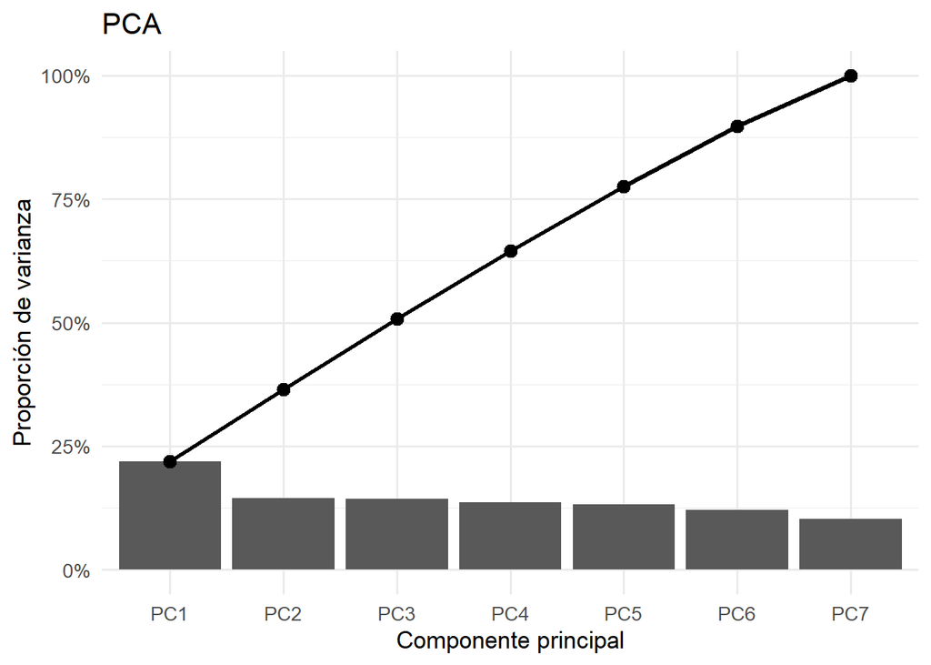

```r
library(scales)

ggplot(df_var, aes(Componente, Varianza)) +
  geom_col() +
  geom_line(aes(y = Acumulada, group = 1), linewidth = 1.1) +
  geom_point(aes(y = Acumulada), size = 3) +
  scale_y_continuous(labels = percent_format()) +
  labs(
    title = "PCA",
    x = "Componente principal",
    y = "Proporción de varianza"
  ) +
  theme_minimal(base_size = 13)
```

### Resultados

El primer componente explica el 22% de la varianza, mientras que el segundo el 14.5%. En conjunto, las primeras dos dimensiones capturan el 36.5% de la variabilidad total. La caída suave en el gráfico (Scree Plot) sugiere que el fenómeno es complejo y depende de múltiples factores con pesos similares.

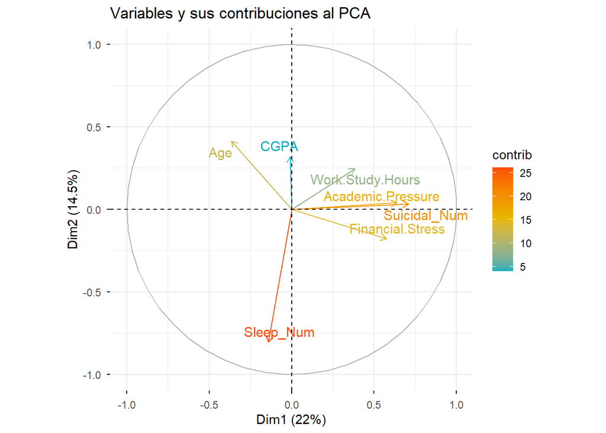

```r
# Círculo de Correlaciones
res_pca <- PCA(data_pca, scale.unit = TRUE, graph = FALSE)

fviz_pca_var(res_pca,
             col.var = "contrib",
             gradient.cols = c("#00AFBB", "#E7B800", "#FC4E07"),
             repel = TRUE,
             title = "Variables y sus contribuciones al PCA")
```

## Visualización de Scores

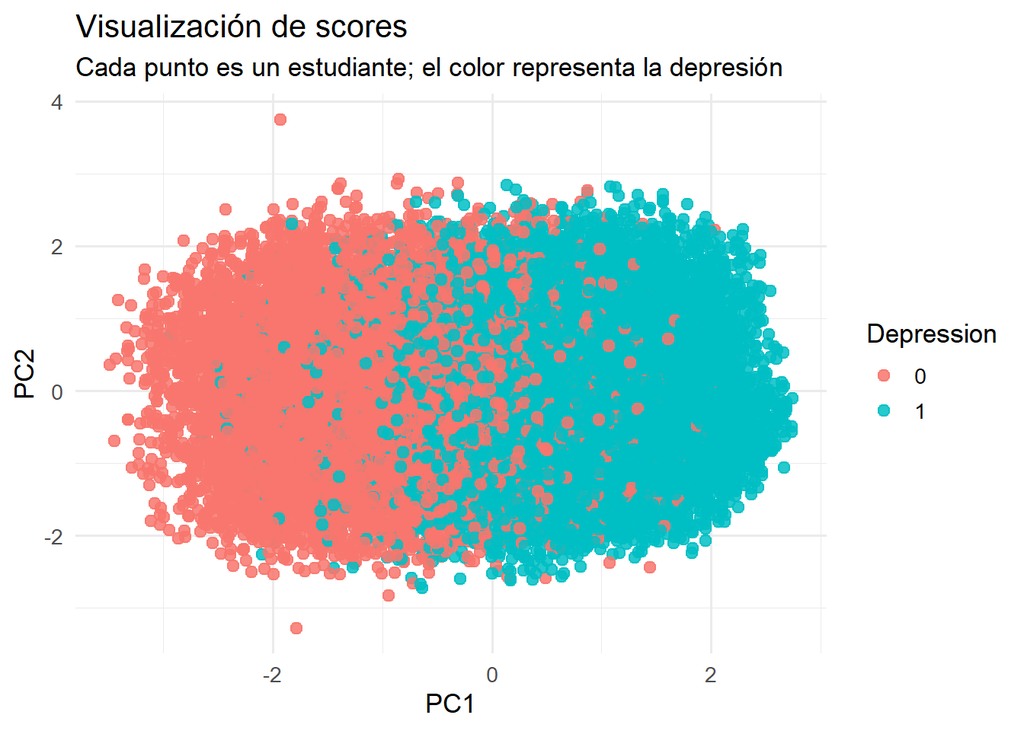

```r
scores_pca <- as.data.frame(pca$x)
scores_pca$Depression <- data_num$Depression

g_scores <- ggplot(scores_pca, aes(PC1, PC2, color = Depression)) +
  geom_point(size = 2.5, alpha = 0.85) +
  labs(
    title = "Visualización de scores",
    subtitle = "Cada punto es un estudiante; el color representa la depresión",
    x = "PC1",
    y = "PC2",
    color = "Depression"
  ) +
  theme_minimal(base_size = 13)

g_scores
```

La nube de datos entre PC1 VS PC2 muestra una separación entre los 2 grupos con coincidencias en el rango de -1 a 1, no es perfecto, aunque las variables en pc1 son las que pueden discriminar a que grupo pertenece el estudiante.

## Visualización de Loadings

```r
loadings_pca <- as.data.frame(pca$rotation)
loadings_pca$Variable <- rownames(pca$rotation)

loadings_pca
```

|  | PC1 | PC2 | PC3 | PC4 | PC5 | PC6 | PC7 | Variable |
| --- | --- | --- | --- | --- | --- | --- | --- | --- |
| Age | -0.293226899 | -0.41052214 | -0.13410980 | -0.551900080 | 0.63718293 | 0.10325608 | -0.07903492 | Age |
| Academic.Pressure | 0.514178259 | -0.03970531 | -0.12387538 | -0.037229693 | 0.31184055 | -0.55228237 | 0.56129555 | Academic.Pressure |
| Work.Study.Hours | 0.309258693 | -0.24451478 | -0.02911180 | -0.676189570 | -0.61187537 | 0.08413872 | 0.07085873 | Work.Study.Hours |
| Financial.Stress | 0.462758719 | 0.17749059 | 0.12701414 | 0.017605242 | 0.27193406 | 0.78034311 | 0.23457498 | Financial.Stress |
| Sleep_Num | -0.112555170 | 0.79809799 | 0.26139506 | -0.485440679 | 0.11862785 | -0.17250777 | -0.05059049 | Sleep_Num |
| CGPA | -0.007476665 | -0.31707825 | 0.93861055 | 0.027928118 | 0.03966334 | -0.10973448 | 0.06341059 | CGPA |
| Suicidal_Num | 0.571950667 | -0.03325139 | 0.01929301 | 0.006733489 | 0.18101944 | -0.16280993 | -0.78235165 | Suicidal_Num |

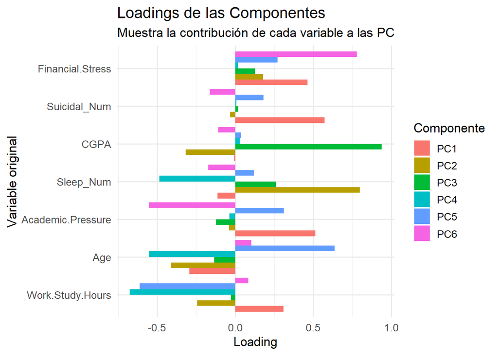

```r
loadings_long <- loadings_pca %>%
  tidyr::pivot_longer(
    cols = starts_with("PC"),
    names_to = "Componente",
    values_to = "Loading"
  )

ggplot(loadings_long %>% filter(Componente %in% c("PC1", "PC2", "PC3", "PC4", "PC5", "PC6")),
       aes(x = reorder(Variable, Loading), y = Loading, fill = Componente)) +
  geom_col(position = "dodge") +
  coord_flip() +
  labs(
    title = "Loadings de las Componentes",
    subtitle = "Muestra la contribución de cada variable a las PC",
    x = "Variable original",
    y = "Loading"
  ) +
  theme_minimal(base_size = 13)
```

En la grafica de loading podemos ver como

- PC1 representa “la carga de nivel academico, financiero” cuando está aumenta existe una tendencia a ideación suicida
- PC2 representa “habitos” como la cantidad de horas de horas de sueño o descanso
- PC3 tiene una carga fuerte al ser casi 1.0 y teniendo proporciones diferentes en los otros componentes se observa que es independiente de otras variables como estrés financiero o presión académica.

## Conclusiones del PCA

# PARTE 10: PCA COMPLETO

```r
library(dplyr)
library(FactoMineR)
library(factoextra)
library(ggplot2)
library(scales)
library(tidyr)

# Seleccionamos TODAS las variables predictoras (excluyendo el target)
data_pca_completo <- data_num %>%
  select(Age, Academic.Pressure, CGPA, Study.Satisfaction,
         Work.Study.Hours, Sleep_Num, Diet_Num, Financial.Stress,
         Suicidal_Num, Family_History_Num)
```

## Normalidad Multivariante

```r
resultado_mardia <- mardia(data_pca_completo)
print(resultado_mardia)
```

```
##              Test  Statistic p.value     Method
## 1 Mardia Skewness 3239.86121       0 asymptotic
## 2 Mardia Kurtosis  -65.16776       0 asymptotic
```

Mardia Skewness (Asimetría): Registra un estadístico de 3239.86 con un p-valor de 0 (exactamente $< 0.05$). Esto significa que los datos presentan una deformación o falta de simetría significativa en su distribución conjunta multidimensional.

Mardia Kurtosis (Curtosis): Registra un estadístico de -65.16 y un p-valor de 0 ($< 0.05$). Al ser significativamente distinto de los valores teóricos de una campana perfecta, indica que las colas de la distribución de los datos son más ligeras o pesadas de lo normal (distribución no platicúrtica/mesocúrtica estándar).

## Dado que ambos p-valores son estrictamente menores a 0.05, se rechaza formalmente la hipótesis nula de normalidad. Los datos NO siguen una distribución normal multivariante. Sin embargo, al tratarse de una muestra sumamente grande ($N \approx 27,868$), las desviaciones de la normalidad matemática son perfectamente normales en variables de comportamiento humano y encuestas. El tamaño de la muestra garantiza que los cálculos posteriores del PCA siguen siendo geométricamente estables y totalmente válidos para describir las relaciones del dataset.

## Nube de datos

Nubes de datos de las variables más correlacionadas.

```r
g_age_suicidal <- ggplot(data_pca_completo, aes(Age, Suicidal_Num)) +
  geom_point(alpha = 0.45, size = 1.6) +
  stat_ellipse(type = "norm", linewidth = 1.1) +
  coord_equal() +
  labs(
    title = "Nube de datos (Age y Suicidal_num)",
    subtitle = "La elipse muestra una dirección natural de máxima variabilidad",
    x = "Age",
    y = "Suicidal_num"
  ) +
  theme_minimal(base_size = 13)

plotly::ggplotly(g_age_suicidal)
```

[interactive chart not shown]

```r
g_academic_financial <- ggplot(data_pca_completo, aes(Academic.Pressure, Financial.Stress)) +
  geom_point(alpha = 0.45, size = 1.6) +
  stat_ellipse(type = "norm", linewidth = 1.1) +
  coord_equal() +
  labs(
    title = "Nube de datos (Academic.Pressure y Financial.Stress)",
    subtitle = "La elipse muestra una dirección natural de máxima variabilidad",
    x = "Academic.Pressure",
    y = " Financial.Stresss"
  ) +
  theme_minimal(base_size = 13)

plotly::ggplotly(g_academic_financial)
```

[interactive chart not shown]

```r
g_academic_suicidal <- ggplot(data_pca_completo, aes(Academic.Pressure, Suicidal_Num)) +
  geom_point(alpha = 0.45, size = 1.6) +
  stat_ellipse(type = "norm", linewidth = 1.1) +
  coord_equal() +
  labs(
    title = "Nube de datos (Academic.Pressure y Suicidal_num)",
    subtitle = "La elipse muestra una dirección natural de máxima variabilidad",
    x = "Academic.Pressure",
    y = "Suicidal_num"
  ) +
  theme_minimal(base_size = 13)

plotly::ggplotly(g_academic_suicidal)
```

[interactive chart not shown]

```r
g_work_suicidal <- ggplot(data_pca_completo, aes(Work.Study.Hours, Suicidal_Num)) +
  geom_point(alpha = 0.45, size = 1.6) +
  stat_ellipse(type = "norm", linewidth = 1.1) +
  coord_equal() +
  labs(
    title = "Nube de datos (Work.Study.Hours y Suicidal_num)",
    subtitle = "La elipse muestra una dirección natural de máxima variabilidad",
    x = "Work.Study.Hours",
    y = "Suicidal_num"
  ) +
  theme_minimal(base_size = 13)

plotly::ggplotly(g_work_suicidal)
```

[interactive chart not shown]

```r
g_financial_suicidal <- ggplot(data_pca_completo, aes(Financial.Stress, Suicidal_Num)) +
  geom_point(alpha = 0.45, size = 1.6) +
  stat_ellipse(type = "norm", linewidth = 1.1) +
  coord_equal() +
  labs(
    title = "Nube de datos (Financial.Stress y Suicidal_num)",
    subtitle = "La elipse muestra una dirección natural de máxima variabilidad",
    x = "Financial.Stress",
    y = "Suicidal_num"
  ) +
  theme_minimal(base_size = 13)

plotly::ggplotly(g_financial_suicidal)
```

[interactive chart not shown]

## Estandarización

```r
summary(data_pca_completo)
```

```
##       Age        Academic.Pressure      CGPA        Study.Satisfaction
##  Min.   :18.00   Min.   :0.000     Min.   : 0.000   Min.   :0.000
##  1st Qu.:21.00   1st Qu.:2.000     1st Qu.: 6.290   1st Qu.:2.000
##  Median :25.00   Median :3.000     Median : 7.770   Median :3.000
##  Mean   :25.82   Mean   :3.141     Mean   : 7.656   Mean   :2.944
##  3rd Qu.:30.00   3rd Qu.:4.000     3rd Qu.: 8.920   3rd Qu.:4.000
##  Max.   :59.00   Max.   :5.000     Max.   :10.000   Max.   :5.000
##  Work.Study.Hours   Sleep_Num        Diet_Num     Financial.Stress
##  Min.   : 0.000   Min.   :4.000   Min.   :1.000   Min.   :1.00
##  1st Qu.: 4.000   1st Qu.:4.000   1st Qu.:1.000   1st Qu.:2.00
##  Median : 8.000   Median :5.500   Median :2.000   Median :3.00
##  Mean   : 7.158   Mean   :6.339   Mean   :1.904   Mean   :3.14
##  3rd Qu.:10.000   3rd Qu.:7.500   3rd Qu.:3.000   3rd Qu.:4.00
##  Max.   :12.000   Max.   :9.000   Max.   :3.000   Max.   :5.00
##   Suicidal_Num    Family_History_Num
##  Min.   :0.0000   Min.   :0.0000
##  1st Qu.:0.0000   1st Qu.:0.0000
##  Median :1.0000   Median :0.0000
##  Mean   :0.6328   Mean   :0.4841
##  3rd Qu.:1.0000   3rd Qu.:1.0000
##  Max.   :1.0000   Max.   :1.0000
```

```r
data_pca_completo <- as.data.frame(scale(data_pca_completo))
summary(data_pca_completo)
```

```
##       Age          Academic.Pressure      CGPA          Study.Satisfaction
##  Min.   :-1.5943   Min.   :-2.2737   Min.   :-5.20599   Min.   :-2.16285
##  1st Qu.:-0.9827   1st Qu.:-0.8261   1st Qu.:-0.92900   1st Qu.:-0.69335
##  Median :-0.1673   Median :-0.1023   Median : 0.07734   Median : 0.04139
##  Mean   : 0.0000   Mean   : 0.0000   Mean   : 0.00000   Mean   : 0.00000
##  3rd Qu.: 0.8519   3rd Qu.: 0.6215   3rd Qu.: 0.85930   3rd Qu.: 0.77614
##  Max.   : 6.7633   Max.   : 1.3453   Max.   : 1.59367   Max.   : 1.51089
##  Work.Study.Hours    Sleep_Num          Diet_Num       Financial.Stress
##  Min.   :-1.9308   Min.   :-1.2198   Min.   :-1.1349   Min.   :-1.48904
##  1st Qu.:-0.8518   1st Qu.:-1.2198   1st Qu.:-1.1349   1st Qu.:-0.79328
##  Median : 0.2271   Median :-0.4375   Median : 0.1199   Median :-0.09752
##  Mean   : 0.0000   Mean   : 0.0000   Mean   : 0.0000   Mean   : 0.00000
##  3rd Qu.: 0.7666   3rd Qu.: 0.6055   3rd Qu.: 1.3746   3rd Qu.: 0.59824
##  Max.   : 1.3061   Max.   : 1.3877   Max.   : 1.3746   Max.   : 1.29400
##   Suicidal_Num     Family_History_Num
##  Min.   :-1.3127   Min.   :-0.9686
##  1st Qu.:-1.3127   1st Qu.:-0.9686
##  Median : 0.7617   Median :-0.9686
##  Mean   : 0.0000   Mean   : 0.0000
##  3rd Qu.: 0.7617   3rd Qu.: 1.0324
##  Max.   : 0.7617   Max.   : 1.0324
```

Al comparar el primer summary() con el segundo, se observa la transformación matemática de los datos. Antes de la transformación, las variables tenían escalas totalmente heterogéneas donde por ejemplo la edad promediaba los 25.8 años con un máximo de 59, mientras que variables como la ideación suicida (Suicidal_Num) o el historial familiar eran binarias (0 o 1).

Tras aplicar scale(), todas las variables cuantitativas pasan a estar en la misma escala métrica:

La media de todas las distribuciones se desplaza exactamente a 0.0000.

Los valores numéricos ahora representan cuántas desviaciones estándar se aleja un estudiante respecto a la media de la muestra. Por ejemplo, un estudiante con el máximo nivel de presión académica está a 1.34 desviaciones estándar por encima del promedio, mientras que el valor máximo de edad (6.76) revela un caso atípico extremo en la distribución de edades.

## Autovalores y Autovectores

```r
S <- cov(data_pca_completo)
eig <- eigen(S)

var_exp <- eig$values / sum(eig$values)

data.frame(
  Componente = paste0("PC", seq_along(eig$values)),
  Autovalor = eig$values,
  Varianza_Explicada = var_exp,
  Varianza_Acumulada = cumsum(var_exp)
)
```

| Componente | Autovalor | Varianza_Explicada | Varianza_Acumulada |
| --- | --- | --- | --- |
| PC1 | 1.6303916 | 0.16303916 | 0.1630392 |
| PC2 | 1.0453585 | 0.10453585 | 0.2675750 |
| PC3 | 1.0252377 | 0.10252377 | 0.3700988 |
| PC4 | 0.9885757 | 0.09885757 | 0.4689563 |
| PC5 | 0.9712189 | 0.09712189 | 0.5660782 |
| PC6 | 0.9535956 | 0.09535956 | 0.6614378 |
| PC7 | 0.9398201 | 0.09398201 | 0.7554198 |
| PC8 | 0.8880558 | 0.08880558 | 0.8442254 |
| PC9 | 0.8366325 | 0.08366325 | 0.9278886 |
| PC10 | 0.7211137 | 0.07211137 | 1.0000000 |

## Análisis de Componentes Principales (PCA)

```r
pca <- prcomp(data_pca_completo, center = TRUE, scale. = TRUE)

summary(pca)
```

```
## Importance of components:
##                          PC1    PC2    PC3     PC4     PC5     PC6     PC7
## Standard deviation     1.277 1.0224 1.0125 0.99427 0.98550 0.97652 0.96944
## Proportion of Variance 0.163 0.1045 0.1025 0.09886 0.09712 0.09536 0.09398
## Cumulative Proportion  0.163 0.2676 0.3701 0.46896 0.56608 0.66144 0.75542
##                            PC8     PC9    PC10
## Standard deviation     0.94237 0.91468 0.84918
## Proportion of Variance 0.08881 0.08366 0.07211
## Cumulative Proportion  0.84423 0.92789 1.00000
```

```r
var <- (pca$sdev^2) / sum(pca$sdev^2)

df_var <- data.frame(
  Componente = paste0("PC", seq_along(var)),
  Varianza = var,
  Acumulada = cumsum(var)
)

df_var
```

| Componente | Varianza | Acumulada |
| --- | --- | --- |
| PC1 | 0.16303916 | 0.1630392 |
| PC2 | 0.10453585 | 0.2675750 |
| PC3 | 0.10252377 | 0.3700988 |
| PC4 | 0.09885757 | 0.4689563 |
| PC5 | 0.09712189 | 0.5660782 |
| PC6 | 0.09535956 | 0.6614378 |
| PC7 | 0.09398201 | 0.7554198 |
| PC8 | 0.08880558 | 0.8442254 |
| PC9 | 0.08366325 | 0.9278886 |
| PC10 | 0.07211137 | 1.0000000 |

[figure not shown]

```r
library(scales)

ggplot(df_var, aes(Componente, Varianza)) +
  geom_col() +
  geom_line(aes(y = Acumulada, group = 1), linewidth = 1.1) +
  geom_point(aes(y = Acumulada), size = 3) +
  scale_y_continuous(labels = percent_format()) +
  labs(
    title = "PCA",
    x = "Componente principal",
    y = "Proporción de varianza"
  ) +
  theme_minimal(base_size = 13)
```

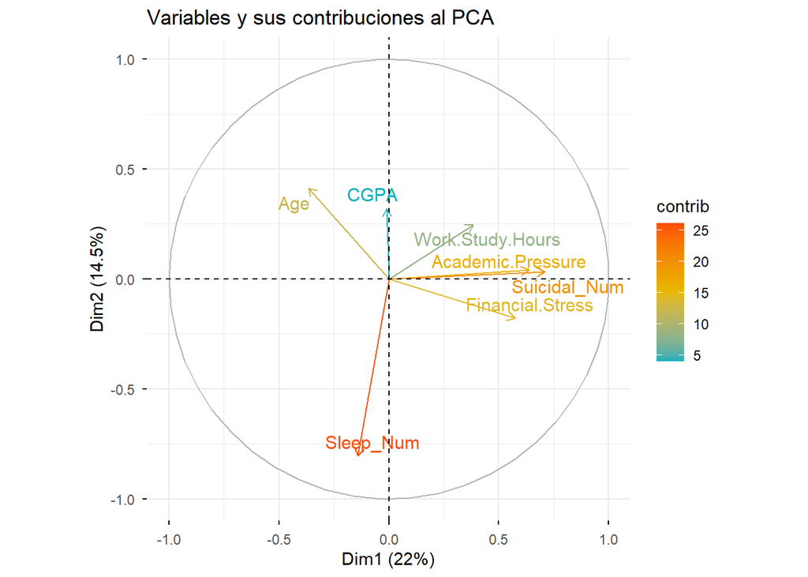

```r
# Círculo de Correlaciones
res_pca <- PCA(data_pca, scale.unit = TRUE, graph = FALSE)

fviz_pca_var(res_pca,
             col.var = "contrib",
             gradient.cols = c("#00AFBB", "#E7B800", "#FC4E07"),
             repel = TRUE,
             title = "Variables y sus contribuciones al PCA")
```

Al examinar los resultados del summary() y los gráficos generados se destaca lo siguiente:

Desviaciones Estándar: Las raíces cuadradas de los autovalores para los tres primeros componentes superan la unidad (PC1 = 1.277, PC2 = 1.022, PC3 = 1.012), mostrando matemáticamente su dominio de información sobre el resto.

En el Scree Plot las barras muestran la proporción de varianza individual decreciente, mientras que la línea continua con puntos mapea el crecimiento de la varianza acumulada, cruzando el umbral del 37% al llegar al tercer nodo.